# Flash ALOHA: Learning Fast and Precise Manipulation · Đọc hiểu học thuật Anh–Việt

Đến nội dung bài báo

Flash ALOHA: Learning Fast and Precise ManipulationChuyên đề đọc hiểu học thuật Anh–Việt · Học phần / mã lớp: chưa được cung cấp

Bản đồ lập luận ↘

Năm chiều phân tích · nhấn để bật/tắt

Annotated paper · Robotics / Imitation learning · EN / VI

# Flash ALOHA: Learning Fast and Precise Manipulation

Học thao tác vừa nhanh, vừa chính xác.

John Hua Yao · Qi Wu · Yihuai Gao · Chelsea Finn · Zipeng Fu

Stanford University · PDF 12 trang · 6 mục chính + 5 phụ lục · 10 hình · 6 bảng

**Luận điểm cần theo dõi**Thu mẫu nhanh trên chính robot, kết hợp mặt nạ hình học và làm trơn hành động, có thể tạo thao tác hai tay vừa nhanh vừa chính xác từ ít dữ liệu.

**50**lượt mẫu / nhiệm vụ  
Phụ lục V

**1.85 s**tung–bắt bóng  
80% · Bảng III

**85%**thành công lắp pin  
5,70 s · Bảng III

**Cách đọc.** Mỗi đơn vị gồm nguyên văn tiếng Anh có tô màu, bản dịch nghĩa tiếng Việt ngay bên dưới, và chú giải tương ứng ở cột phải. Trên điện thoại, chú giải nằm sau bản dịch. Số § là mã đoạn của bản đọc này; số trang dẫn về PDF.

**Phạm vi biên tập.** Bao gồm toàn bộ văn xuôi chính, lời cảm ơn, năm phụ lục, chú thích 10 hình, số liệu của sáu bảng và 59 tài liệu tham khảo. Chỉ nối lại dòng / từ bị ngắt do dàn trang và chuẩn hóa ký hiệu công thức; bảng rộng được tách theo nhiệm vụ, phụ lục đặt trước danh mục tham khảo để đọc liền mạch. Bản dịch và chú giải là biên soạn hỗ trợ học thuật, không phải nội dung do tác giả viết.

**Nguồn.** [PDF do người đọc cung cấp (v=2)](https://johnyao93.github.io/static/files/flash-aloha.pdf?v=2) · [Trang dự án & video](https://johnyao93.github.io/flash-aloha/). Luận cứ và số liệu trong bản đọc dựa vào PDF; video dự án chỉ cung cấp bối cảnh, không được xem là kiểm chứng độc lập. Tệp hoạt động ngoại tuyến: font, hình, CSS và JavaScript đều được nhúng.

01 / Nguyên văn tiếng Anh + bản dịch tiếng Việt02 / Chức năng · Vai trò logic · Đánh giá

00

## Abstract Tóm tắt

Vấn đề, giải pháp và tuyên bố trung tâm

§01PDF tr. 1EN → VI

Learning from human demonstrations has enabled robots to acquire a wide range of manipulation skills, but learned policies typically execute far slower than ordinary humans. This speed gap is mainly due to lack of an interface for precisely collecting demonstration data at high speed, and the difficulty in training policies that can robustly execute high-speed motions. In this paper, we present Flash ALOHA, a practical system for learning fast and precise robotic manipulation. Our system uses kinesthetic teaching to intuitively collect accurate and near-human-speed demonstrations on a backdrivable bimanual platform, yielding natural and fast trajectories. Our learning pipeline consists of two components: a lightweight smoothing algorithm to address tracking instabilities produced by action chunking, and for visual alignment we mask out the operator visible in the camera views. Given 50 demonstrations for each task, Flash ALOHA autonomously completes bimanual tasks such as ball tossing and catching, folding shorts, battery insertion, and bussing tables at over 80% success rates while close to human speed.

Bản dịch tiếng Việt

Học từ thao tác mẫu của con người đã giúp robot tiếp thu nhiều kỹ năng thao tác, nhưng các chính sách học được thường thực thi chậm hơn nhiều so với người bình thường. Khoảng cách tốc độ này chủ yếu bắt nguồn từ việc thiếu giao diện thu thập chính xác dữ liệu mẫu ở tốc độ cao, đồng thời khó huấn luyện chính sách có thể thực hiện ổn định các chuyển động nhanh. Trong bài báo này, chúng tôi giới thiệu Flash ALOHA, một hệ thống thực tiễn để học thao tác robot vừa nhanh vừa chính xác. Hệ thống sử dụng phương pháp dạy học bằng dẫn động trực tiếp: người vận hành hướng dẫn một nền tảng hai tay máy có khả năng dẫn động ngược, nhờ đó thu được các quỹ đạo tự nhiên, chính xác và gần tốc độ con người. Quy trình học gồm hai thành phần: thuật toán làm trơn gọn nhẹ nhằm khắc phục sự mất ổn định khi bám quỹ đạo do phân đoạn hành động, và mặt nạ hình ảnh để loại bỏ người vận hành khỏi các góc nhìn camera, qua đó đồng nhất miền thị giác. Với 50 lượt thao tác mẫu cho mỗi nhiệm vụ, Flash ALOHA tự thực hiện các tác vụ hai tay như tung–bắt bóng, gấp quần đùi, lắp pin và dọn bàn với tỷ lệ thành công trên 80%, đồng thời đạt tốc độ gần với con người.

§01 · Luận đề

### Tóm lược luận đề và đóng góp

**Vai trò logic**

Đặt toàn bộ chuỗi vấn đề → giải pháp phần cứng và học máy → kết quả vào một đoạn.

**Thủ pháp / điểm cần xét**

Cần đọc tuyên bố ‘trên 80%’ cùng Bảng III: tung–bắt bóng đạt đúng 80%. ‘Gần tốc độ con người’ cũng không đồng nghĩa với một phép đo đối chứng toàn diện cho cả năm tác vụ.

[figure not shown]

Fig. 1: Flash ALOHA. We present a full-stack system for learning precise and high-speed manipulation policies, which can autonomously do bimanual toss and catch in under 2 seconds, bus a full dining set under 7, and fold a pair of shorts under 6.

Chú thích hình · tiếng Việt

Flash ALOHA là hệ thống hoàn chỉnh học thao tác chính xác ở tốc độ cao: tự tung–bắt bóng dưới 2 giây, dọn bộ đồ ăn dưới 7 giây và gấp quần đùi dưới 6 giây.

Hình 1 · Bằng chứng

### Minh họa năng lực

**Vai trò logic**

Đặt năm nhiệm vụ vào bối cảnh thị giác trước khi đọc chi tiết kết quả.

**Thủ pháp / điểm cần xét**

Các ảnh là minh họa, không phải phân bố thống kê. Nhãn gấp quần trong hình ghi 5,91 s, trong khi Bảng I–II ghi 5,94 s; phần tổng hợp dùng số trong bảng.

I

## Introduction Mở đầu

Vì sao robot cần học từ dữ liệu nhanh?

§02PDF tr. 1EN → VI

Learning from human demonstrations has proven to be a powerful paradigm for teaching robots a wide array of complex skills. We have seen robots learn everything from fine-grained manipulation tasks such as threading a shoelace and lighting a match to mobile manipulation tasks such as sauteing and serving shrimp [1]–[3]. However, despite these successes, a significant gap remains between robotic and human performance: speed. While a person can perform many everyday chores with fluid and rapid motions, policies learned from demonstration typically execute with a slow and deliberate pace that feels distinctly non-human. This disparity is more than just an aesthetic issue; it is a fundamental barrier to deploying robots in practical human-centric environments where efficiency and responsiveness are important. For time-sensitive tasks like cooking and serving food, or collaborative tasks requiring synchronization with humans, the value of a robotic assistant diminishes greatly if it performs these tasks at a fraction of human speed.

Bản dịch tiếng Việt

Học từ thao tác mẫu của con người đã chứng tỏ là một cách tiếp cận hiệu quả để dạy robot nhiều kỹ năng phức tạp. Robot đã học được từ những thao tác tinh như xỏ dây giày, quẹt diêm cho đến các thao tác di động như xào và phục vụ tôm [1]–[3]. Tuy nhiên, giữa thành tích của robot và con người vẫn còn một khoảng cách đáng kể: tốc độ. Con người thường làm việc nhà bằng những chuyển động nhanh và liền mạch, trong khi chính sách học từ mẫu thường thực hiện chậm rãi, thận trọng và thiếu tự nhiên. Khác biệt này không chỉ liên quan đến cảm nhận thẩm mỹ, mà còn là rào cản căn bản khi triển khai robot trong môi trường lấy con người làm trung tâm, nơi hiệu suất và khả năng phản ứng rất quan trọng. Trong các công việc nhạy về thời gian như nấu và phục vụ thức ăn, hoặc công việc cộng tác đòi hỏi phối hợp nhịp nhàng với con người, giá trị của trợ lý robot giảm mạnh nếu nó chỉ làm việc với một phần tốc độ của con người.

§02 · Luận đề

### Nêu vấn đề và xác lập tính cấp thiết

**Vai trò logic**

Chuyển tiêu chí đánh giá từ ‘làm được’ sang ‘làm được đủ nhanh để hữu ích’.

**Thủ pháp / điểm cần xét**

Lập luận dựa vào hệ quả thực tiễn và đối lập người–robot. Các ví dụ triển khai tạo động lực nghiên cứu, chưa phải bằng chứng hệ thống đã sẵn sàng cho môi trường thực tế.

§03PDF tr. 1–2EN → VI

The root of this speed gap lies in two challenges. First, there is a lack of accessible systems for collecting demonstration data that capture the dynamics of human-speed motion. Teleoperation interfaces based on puppeteering [1], 3D mice [4], or VR controllers [5] are not designed for high-speed interaction, due to latency, unintuitive control, and limited sensory feedback for human operators, causing heavy mental load for human operators. This forces human operators to move slowly and carefully, resulting in datasets of sluggish trajectories. The policy, in turn, learns to imitate this slow behavior. Handheld devices [6] offer the benefit of more intuitive data collection, and promise scalability by avoiding demonstrations on real robots. However, such devices commonly rely on visual and inertial information for localization, and completely fail in pose estimation for high speed motions (Fig. 2b). State of the art visual-inertial tracking systems degrade quickly with speed, seen in Fig. 2a.

Bản dịch tiếng Việt

Khoảng cách tốc độ này có hai nguyên nhân chính. Thứ nhất, hiện thiếu những hệ thống dễ tiếp cận để thu thập dữ liệu mẫu phản ánh động lực học của chuyển động ở tốc độ con người. Các giao diện điều khiển từ xa như tay dẫn động kiểu con rối [1], chuột 3D [4] hay bộ điều khiển thực tế ảo [5] không được thiết kế cho tương tác tốc độ cao: độ trễ, cách điều khiển thiếu trực quan và phản hồi cảm giác hạn chế làm tăng gánh nặng nhận thức của người vận hành. Vì vậy, họ phải di chuyển chậm và cẩn thận, tạo ra dữ liệu quỹ đạo chậm; chính sách sau đó cũng học theo hành vi ấy. Thiết bị cầm tay [6] giúp thu thập dữ liệu trực quan hơn và hứa hẹn khả năng mở rộng vì không cần thực hiện mẫu trực tiếp trên robot. Tuy nhiên, các thiết bị này thường dựa vào tín hiệu thị giác và quán tính để định vị, và có thể thất bại hoàn toàn khi ước lượng tư thế trong chuyển động nhanh (Hình 2b). Như Hình 2a cho thấy, chất lượng theo dõi thị giác–quán tính tiên tiến suy giảm nhanh khi tốc độ tăng.

§03 · Khái niệm

### Chẩn đoán nút thắt ở dữ liệu

**Vai trò logic**

Gắn tốc độ của chính sách với chất lượng và tốc độ của giao diện thu thập mẫu.

**Thủ pháp / điểm cần xét**

Đây là chuỗi nhân quả hợp lý, nhưng phát biểu về các hệ thống theo dõi tiên tiến rộng hơn phép thử iPhone/ARKit cụ thể trong Phụ lục II. Không nên suy rộng thành mọi thiết bị cầm tay đều thất bại.

§04PDF tr. 2EN → VI

Second, even after assuming near perfect recording, learning a policy that can reliably execute these motions is a significant hurdle. Using recorded positions as actions as in handheld devices [6] assumes perfectly reaching every commanded position on time, requiring high torques at high speeds. Discontinuities from action chunking create catastrophic instability. Additionally, position data may not always include all necessary information for forceful manipulation, such as when pressing hard on near stationary objects. Visually, having the operator in view of the camera when directly moving the robot also can confuse the policy.

Bản dịch tiếng Việt

Thứ hai, ngay cả khi giả định quá trình ghi nhận gần như hoàn hảo, học một chính sách có thể thực hiện tin cậy những chuyển động ấy vẫn là thách thức lớn. Dùng các vị trí đã ghi làm hành động, như trong thiết bị cầm tay [6], ngầm giả định robot đạt đúng từng vị trí yêu cầu đúng thời điểm; ở tốc độ cao, điều này đòi hỏi mô-men xoắn lớn. Sự gián đoạn giữa các đoạn hành động có thể gây mất ổn định nghiêm trọng. Hơn nữa, dữ liệu vị trí không phải lúc nào cũng chứa đủ thông tin cho các thao tác cần lực, chẳng hạn ấn mạnh vào vật gần như đứng yên. Về thị giác, sự xuất hiện của người vận hành trong camera khi trực tiếp di chuyển robot cũng có thể khiến chính sách nhầm lẫn.

§04 · Khái niệm

### Chẩn đoán nút thắt ở thực thi

**Vai trò logic**

Bổ sung điều kiện thứ hai: có dữ liệu nhanh là cần thiết nhưng chưa đủ để thực thi nhanh và ổn định.

**Thủ pháp / điểm cần xét**

Đoạn này phân biệt ba vấn đề: giới hạn động lực học, gián đoạn lệnh và lệch miền hình ảnh. Hệ thống đề xuất xử lý hai vấn đề sau rõ ràng hơn vấn đề thiếu thông tin lực.

§05PDF tr. 2EN → VI

To address these issues, we introduce Flash ALOHA, a practical system for directly learning near human speed bimanual manipulation from human demonstrations. During data collection, the end effectors of lightweight robot arms are attached with two scissor handles for human operators to backdrive the arms under gravity and friction compensation. This method of direct physical guidance provides operators with rich real-time sensory feedback in vision, haptics, and sound, enabling high speed, precise, and contact rich data collection. The arms’ motor encoders provide precise position readings even under aggressive motion, avoiding pose estimation issues. To ensure that position trajectories produce effective policies, operators at collection time may directly replay recorded trajectories on the arms between episodes, catching any tracking issues that may arise due to missing action data.

Bản dịch tiếng Việt

Để giải quyết các vấn đề trên, chúng tôi giới thiệu Flash ALOHA, một hệ thống thực tiễn cho phép học trực tiếp thao tác hai tay ở tốc độ gần con người từ các lượt làm mẫu. Khi thu thập dữ liệu, đầu công tác của các tay máy nhẹ được gắn tay cầm dạng kéo; người vận hành dẫn động ngược tay máy với sự hỗ trợ bù trọng lực và ma sát. Việc hướng dẫn trực tiếp này cung cấp tức thời thông tin thị giác, xúc giác và âm thanh phong phú, giúp thu thập các thao tác nhanh, chính xác và giàu tiếp xúc. Bộ mã hóa động cơ của tay máy cho số đo vị trí chính xác ngay cả khi chuyển động mạnh, tránh được vấn đề ước lượng tư thế. Để bảo đảm quỹ đạo vị trí có thể tạo ra chính sách hiệu quả, giữa các lượt thu thập, người vận hành có thể phát lại quỹ đạo đã ghi trên robot nhằm phát hiện lỗi bám quỹ đạo do thông tin hành động còn thiếu.

§05 · Phương pháp

### Đề xuất giải pháp phần cứng

**Vai trò logic**

Đáp lại nút thắt dữ liệu bằng việc đồng nhất cơ thể được làm mẫu với cơ thể robot sẽ thực thi.

**Thủ pháp / điểm cần xét**

Cơ chế phản hồi phong phú áp dụng cho người làm mẫu; robot tự hành không vì thế có cảm biến xúc giác. Phát lại quỹ đạo là kiểm tra tính khả thi hữu ích nhưng chưa bảo đảm khả năng khái quát của chính sách.

§06PDF tr. 2EN → VI

We present a learning pipeline for high-speed manipulation data. Our approach incorporates two key techniques. First, to ensure smooth execution, we introduce test-time smoothing, a post-hoc real-time processing for smooth transitions between action chunks. This method helps mitigate jerkiness at high speed that can arise from action chunking, allowing the robot to perform fast motions without sacrificing stability. Second, to address the visual domain shift from a human operator being present with hands holding the robot end-effectors, we employ a masking technique to align the visual domains between collection and deployment. By removing regions with human hands appearing in cameras via an analytical model, we align the visual input distributions. We find that while performance remains high without visual alignment, masking further improves performance.

Bản dịch tiếng Việt

Chúng tôi xây dựng một quy trình học dành cho dữ liệu thao tác tốc độ cao với hai kỹ thuật chính. Trước hết, để thực thi êm, chúng tôi đưa vào bước làm trơn tại thời điểm chạy: xử lý hậu kỳ theo thời gian thực để chuyển tiếp mượt giữa các đoạn hành động. Cách này giảm chuyển động giật do phân đoạn hành động ở tốc độ cao, giúp robot chuyển động nhanh mà vẫn ổn định. Thứ hai, để xử lý sự khác biệt thị giác do bàn tay người vận hành đang giữ đầu công tác trong dữ liệu mẫu, chúng tôi dùng mặt nạ để đồng nhất miền hình ảnh giữa thu thập và triển khai. Các vùng có bàn tay người được loại bỏ bằng một mô hình giải tích, giúp phân bố đầu vào thị giác nhất quán hơn. Chúng tôi nhận thấy hiệu năng vẫn cao khi chưa đồng nhất thị giác, nhưng mặt nạ còn cải thiện thêm kết quả.

§06 · Phương pháp

### Đề xuất hai thành phần thuật toán

**Vai trò logic**

Nối hai vấn đề thực thi với hai can thiệp tương ứng: làm trơn lệnh và che người vận hành.

**Thủ pháp / điểm cần xét**

Nhượng bộ rằng không che vẫn hoạt động tốt giúp giới hạn mức độ cần thiết của mặt nạ; tác dụng của nó cần được xác nhận bằng so sánh loại bỏ thành phần ở Mục V.C.

§07PDF tr. 2EN → VI

The synergy between our intuitive hardware for near-human-speed data collection and our robust learning pipeline allows Flash ALOHA to learn fast, complex tasks from a small number of demonstrations. With only 50 demonstrations per task, our system learns to autonomously perform fine-grained tasks such as tossing a ball from one arm and catching it with the other, folding chino shorts, bussing a table, inserting a battery into a remote, and unstacking plastic cups, achieving over 80% success rates. Critically, these tasks are completed at speeds that are close to average human speeds, reducing the execution time by over 50% compared to that of teleoperation systems, and represent a significant step towards creating robots that can operate efficiently in the real world.

Bản dịch tiếng Việt

Sự kết hợp giữa phần cứng trực quan cho phép thu thập dữ liệu gần tốc độ con người và quy trình học ổn định giúp Flash ALOHA học những tác vụ nhanh, phức tạp từ ít lượt mẫu. Chỉ với 50 lượt mẫu cho mỗi nhiệm vụ, hệ thống có thể tự thực hiện các thao tác tinh như một tay tung bóng để tay kia bắt, gấp quần đùi chino, dọn bàn, lắp pin vào điều khiển từ xa và tách cốc nhựa, với tỷ lệ thành công trên 80%. Quan trọng hơn, các nhiệm vụ được hoàn thành ở tốc độ gần tốc độ trung bình của con người và giảm hơn 50% thời gian thực thi so với các hệ thống điều khiển từ xa. Đây là một bước tiến đáng kể hướng tới robot có thể làm việc hiệu quả trong thế giới thực.

§07 · Luận đề

### Khẳng định đóng góp thực nghiệm

**Vai trò logic**

Chốt phần mở đầu bằng các tiêu chí có thể kiểm chứng: số mẫu, tỷ lệ thành công và thời gian.

**Thủ pháp / điểm cần xét**

Bảng III hỗ trợ mức giảm hơn 50% cho ba tác vụ có đối chứng puppeteering. Không có đối chứng tương tự cho cả năm tác vụ; tung–bắt bóng đạt 80%, không phải trên 80%.

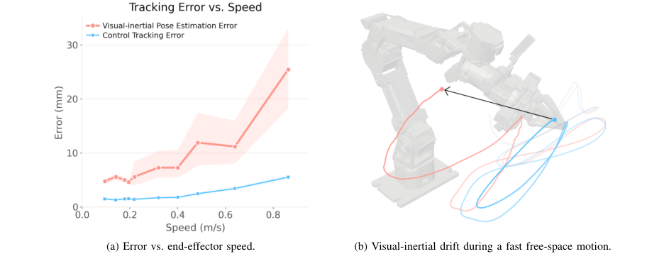

Fig. 2: Visual-Inertial Pose Estimation vs. Control Tracking. (a) Average error in 1 s windows over replayed action trajectories, binned by end-effector speed. (b) End effector trajectory of a recording test from the robot’s encoders (blue) and a wrist-mounted visual-inertial tracker (red), a drift of over 10 cm. Per-task policy rollouts and setup details can be found in Appendix I, II.

Chú thích hình · tiếng Việt

So sánh ước lượng tư thế thị giác–quán tính và bám lệnh điều khiển. (a) Sai số trung bình trong cửa sổ 1 giây trên quỹ đạo phát lại, chia nhóm theo tốc độ đầu công tác. (b) Quỹ đạo encoder (xanh) và tracker thị giác–quán tính ở cổ tay (đỏ), với độ trôi vượt 10 cm. Chi tiết cấu hình và chạy chính sách ở Phụ lục I–II.

Hình 2 · Bằng chứng

### Động cơ cho dữ liệu encoder

**Vai trò logic**

Hỗ trợ nhận định chất lượng theo dõi ngoài robot suy giảm khi chuyển động nhanh.

**Thủ pháp / điểm cần xét**

Xem Phụ lục II để biết căn chỉnh thời gian, phép khớp hệ tọa độ và tiêu chí loại bản ghi; không suy rộng sang mọi tracker.

II

## Related Work Nghiên cứu liên quan

Đặt đóng góp vào ba dòng nghiên cứu

§08PDF tr. 3EN → VI

Learning from Demonstrations. Learning from demonstrations, or imitation learning, is a cornerstone of modern robotics, enabling robots to acquire complex skills by mimicking expert demonstrations [7]. The efficacy of this paradigm is heavily dependent on the interface used for data collection. A wide spectrum of interfaces has been explored, ranging from processing human videos to various forms of interactive teleoperation. While human videos offer immense scale and diversity, they introduce significant embodiment and observation gaps that complicate direct policy learning [8]–[10]. Teleop methods aim to reduce this gap. Common low-cost interfaces include keyboards [11], 3D space mice [12], game controllers [13] and phones [14], though they can be unintuitive for controlling 6-DoF motion. More immersive interfaces, such as Virtual Reality controllers, provide more direct 6-DoF end-effector control but can suffer from latency, a lack of haptic feedback, and a lack of feedback on kinematic constraints [5], [15]– [17]. Other approaches shadow human motion in real time or offline using real-time pose estimation [18]–[21], exoskeletons [22], [23] and vision-based tracking [6], [24], [25], capturing natural kinematics but still facing the human-to-robot correspondence problem. To achieve a more direct mapping, leader-follower puppeteering systems provide secondary leader devices that the operator manipulates to control the follower robots providing intuitive joint-space control [1], [2], [26]–[30]. In contrast to these methods, Flash ALOHA utilizes kinesthetic teaching where human operators directly hold and guide the robot motion, eliminating the cost and complexity of a duplicate leader setup for puppeteering and bypassing the latency or embodiment gap inherent in other interfaces.

Bản dịch tiếng Việt

Học từ thao tác mẫu. Học từ thao tác mẫu, hay học bắt chước, là nền tảng của robot học hiện đại, giúp robot tiếp thu kỹ năng phức tạp bằng cách mô phỏng chuyên gia [7]. Hiệu quả của cách tiếp cận này phụ thuộc lớn vào giao diện thu thập dữ liệu. Các giao diện đã được nghiên cứu trải dài từ xử lý video con người đến nhiều hình thức điều khiển từ xa tương tác. Video con người có quy mô và độ đa dạng lớn, nhưng khác biệt về cơ thể và quan sát khiến việc học trực tiếp chính sách trở nên khó khăn [8]–[10]. Điều khiển từ xa nhằm thu hẹp khoảng cách ấy. Các giao diện giá rẻ như bàn phím [11], chuột không gian 3D [12], tay cầm trò chơi [13] và điện thoại [14] có thể thiếu trực quan khi điều khiển chuyển động sáu bậc tự do. Bộ điều khiển thực tế ảo cho phép điều khiển đầu công tác sáu bậc tự do trực tiếp hơn, song vẫn có thể chịu độ trễ và thiếu phản hồi xúc giác hoặc thông tin về ràng buộc động học [5], [15]–[17]. Những hướng khác bám theo chuyển động người trực tiếp hoặc ngoại tuyến bằng ước lượng tư thế [18]–[21], bộ khung ngoài [22], [23] hay theo dõi thị giác [6], [24], [25], nhưng vẫn phải giải quyết ánh xạ giữa cơ thể người và robot. Để ánh xạ trực tiếp hơn, hệ thống tay dẫn–tay theo dùng thiết bị dẫn phụ mà người vận hành thao tác để điều khiển robot theo trong không gian khớp [1], [2], [26]–[30]. Trái lại, Flash ALOHA sử dụng cách dạy bằng dẫn động trực tiếp: người vận hành giữ và hướng dẫn chính robot, loại bỏ chi phí và độ phức tạp của bộ tay dẫn trùng lặp, đồng thời tránh độ trễ hay sai khác cơ thể vốn có ở các giao diện khác.

§08 · Khái niệm

### Định vị trong học bắt chước

**Vai trò logic**

So sánh các họ giao diện để xác định lựa chọn thiết kế của Flash ALOHA.

**Thủ pháp / điểm cần xét**

Đây là lập luận bằng phân loại và đối chiếu. Ưu điểm trực tiếp phải đánh đổi bằng nhu cầu có robot ngay tại nơi thu mẫu, khác với tính mở rộng của video hoặc thiết bị cầm tay.

§09PDF tr. 3EN → VI

Kinesthetic Teaching. Kinesthetic teaching, where an operator physically guides a robot’s end-effector through a task, is one of the most direct and intuitive methods for programming robot behaviors [7]. By moving the robot by hand, the demonstrator can implicitly convey not only the desired trajectory but also information about contact points and forces. This method requires the robot to be either passively compliant or actively backdrivable, often necessitating gravity compensation to make the robot feel “weightless” and reduce operator fatigue. Early work demonstrated the effectiveness of this approach for learning simple trajectories and dynamic movement primitives [31]–[37]. However, a primary challenge has been the difficulty of recording fast, dynamic motions due to robot inertia and motor friction, which can make the robot feel sluggish and heavy to the operator. Furthermore, the physical presence of the human operator in the workspace during demonstration can create a visual domain shift, as the policy is later deployed in a scene without the operator’s hands and arms. Flash ALOHA addresses the challenge of collecting high-speed data by using a lightweight backdrivable bimanual platform with low-gear-ratio actuators with real-time gravity compensation along with an ergonomic scissor handle design, significantly reducing operator effort. Optional motor friction compensation and gripper gear upsizing further reduce operator fatigue and improve trajectory quality. Together with our masking and real-time smoothing, Flash ALOHA can capture and learn end-to-end policies for precise and fast skills from fluid, near-human-speed motions that are difficult to obtain and execute with kinesthetic teaching systems.

Bản dịch tiếng Việt

Dạy bằng dẫn động trực tiếp. Trong phương pháp này, người vận hành trực tiếp đưa đầu công tác của robot đi qua một nhiệm vụ; đây là một trong những cách lập trình hành vi robot trực quan nhất [7]. Khi di chuyển robot bằng tay, người làm mẫu có thể truyền đạt ngầm cả quỹ đạo, điểm tiếp xúc và lực. Robot phải có độ mềm dẻo thụ động hoặc khả năng dẫn động ngược chủ động; thường cần bù trọng lực để tạo cảm giác ‘không trọng lượng’ và giảm mệt mỏi. Các nghiên cứu ban đầu cho thấy hiệu quả khi học quỹ đạo đơn giản và các mẫu chuyển động cơ sở (dynamic movement primitives) [31]–[37]. Tuy nhiên, quán tính robot và ma sát động cơ khiến việc ghi chuyển động nhanh, giàu động lực học trở nên khó khăn, vì người vận hành cảm thấy tay máy nặng và chậm. Sự có mặt của người trong vùng làm việc cũng gây lệch miền thị giác khi triển khai chính sách mà không còn tay người. Flash ALOHA xử lý việc thu dữ liệu nhanh bằng nền tảng hai tay máy nhẹ, bộ truyền động tỷ số truyền thấp, bù trọng lực thời gian thực và tay cầm dạng kéo thuận tiện, qua đó giảm đáng kể công sức vận hành. Bù ma sát động cơ và tăng kích thước bánh răng bộ kẹp là các cải tiến tùy chọn giúp giảm mỏi và cải thiện quỹ đạo. Kết hợp với mặt nạ và làm trơn thời gian thực, hệ thống có thể ghi nhận và học chính sách đầu-cuối cho các kỹ năng chính xác, nhanh từ chuyển động liền mạch gần tốc độ con người—những dữ liệu khó thu và khó thực thi bằng các hệ thống dạy dẫn động trực tiếp trước đây.

§09 · Phương pháp

### Xác định khoảng trống trong phương pháp gần nhất

**Vai trò logic**

Cho thấy đóng góp là khắc phục các rào cản của một phương pháp đã có, thay vì phát minh phương pháp dạy mới.

**Thủ pháp / điểm cần xét**

Giải thích cơ học khá rõ, nhưng không có thí nghiệm tách riêng đóng góp của từng cải tiến tay cầm, ma sát và tỷ số truyền. ‘Truyền đạt lực’ trong làm mẫu không đồng nghĩa chính sách quan sát được lực.

§10PDF tr. 3EN → VI

High-Speed Manipulation. Achieving human-level speed in manipulation is a long-standing goal in robotics, crucial for applications where efficiency is paramount. Traditional approaches to high-speed robotics often rely on precise analytical models of robot and object dynamics, using techniques like trajectory optimization to generate feasible, time-optimal paths. These methods have enabled impressive feats, such as industrial robots performing rapid pick-and-place operations or research platforms batting [38], playing table tennis [39]–[43], moving objects and avoiding collisions at speed [44], tossing [45], dynamically manipulating deformable objects [46]–[48], and catching objects in mid-air [49]. However, these approaches typically require extensive, task-specific engineering and can be brittle to unmodeled contact dynamics or perturbations. Learning-based methods offer a promising alternative by acquiring dynamic skills directly from data. However, a primary bottleneck has been the lack of systems capable of collecting demonstration data that captures near-human-speed motion [50], [51].

Bản dịch tiếng Việt

Thao tác tốc độ cao. Đạt tốc độ thao tác ngang con người từ lâu là mục tiêu của robot học, đặc biệt ở các ứng dụng coi trọng hiệu suất. Phương pháp truyền thống thường dựa trên mô hình giải tích chính xác của động lực học robot và vật thể, kết hợp tối ưu hóa quỹ đạo để tạo đường đi khả thi, tối ưu thời gian. Chúng đã tạo ra những thành tựu như gắp–đặt nhanh trong công nghiệp, đánh bóng [38], chơi bóng bàn [39]–[43], vận chuyển vật và tránh va chạm ở tốc độ cao [44], ném vật [45], thao tác động với vật biến dạng [46]–[48] và bắt vật đang bay [49]. Tuy vậy, các cách này thường cần nhiều thiết kế riêng cho từng nhiệm vụ và có thể thiếu bền vững trước động lực học tiếp xúc hoặc nhiễu chưa được mô hình hóa. Học trực tiếp từ dữ liệu là một hướng thay thế đầy hứa hẹn. Nút thắt chính vẫn là thiếu hệ thống thu dữ liệu mẫu phản ánh được chuyển động gần tốc độ con người [50], [51].

§10 · Khái niệm

### Đối chiếu với điều khiển dựa trên mô hình

**Vai trò logic**

Giải thích vì sao việc học từ mẫu nhanh là một hướng đóng góp riêng dù robot tốc độ cao đã tồn tại.

**Thủ pháp / điểm cần xét**

Lập luận không phủ nhận thành tựu trước; nó phân biệt kỹ năng chuyên dụng với quy trình học. Bài báo không trực tiếp so sánh với một bộ điều khiển tối ưu quỹ đạo cho cùng tác vụ.

§11PDF tr. 3EN → VI

Furthermore, even with a suitable dataset, learning a policy to robustly execute fast motions is a significant hurdle [6], [52], [53]. Fast movements are less forgiving, where latency discrepancies can cause out-of-sync actions, and discontinuous commands from a policy can lead to instability.

Bản dịch tiếng Việt

Hơn nữa, ngay cả khi đã có tập dữ liệu phù hợp, học một chính sách có thể thực hiện ổn định các chuyển động nhanh vẫn là thách thức lớn [6], [52], [53]. Chuyển động nhanh ít dung sai hơn: chênh lệch độ trễ có thể khiến hành động lệch nhịp, còn các lệnh không liên tục từ chính sách có thể gây mất ổn định.

§11 · Khái niệm

### Củng cố yêu cầu về độ ổn định

**Vai trò logic**

Từ tổng quan quay lại nút thắt thứ hai, chuẩn bị cho giải pháp làm trơn.

**Thủ pháp / điểm cần xét**

Đây là biện minh cơ chế, chưa phải định lượng độ nhạy theo tốc độ hay một chứng minh ổn định của bộ điều khiển.

§12PDF tr. 3EN → VI

Orthogonal to collecting high speed human data, reinforcement learning may also be used to collect high speed data while preserving effectiveness. Such approaches typically explicitly model speed as an objective [51], [52], [54]. Other speedup approaches also include using different action representations that provide analytical representations of trajectories for speedup [55]. Flash ALOHA is complementary to these approaches, by allowing operators to directly train high speed policies without refinement.

Bản dịch tiếng Việt

Bên cạnh việc thu dữ liệu nhanh từ con người, học tăng cường cũng có thể được dùng để tạo dữ liệu tốc độ cao mà vẫn duy trì hiệu quả. Các phương pháp này thường mô hình hóa tốc độ thành mục tiêu tối ưu tường minh [51], [52], [54]. Một hướng tăng tốc khác là dùng biểu diễn hành động khác, trong đó quỹ đạo có dạng giải tích thuận tiện cho việc tăng tốc [55]. Flash ALOHA bổ trợ cho những hướng đó vì cho phép người vận hành huấn luyện trực tiếp chính sách tốc độ cao mà không cần bước tinh chỉnh.

§12 · Nhượng bộ / phản biện

### Thừa nhận hướng thay thế và giới hạn phạm vi

**Vai trò logic**

Định vị đóng góp là bổ trợ, không phải giải pháp duy nhất để tăng tốc.

**Thủ pháp / điểm cần xét**

Nhượng bộ giúp tránh thế lưỡng phân giả giữa làm mẫu nhanh và tăng tốc chính sách. Khả năng kết hợp với các phương pháp được nêu vẫn là triển vọng, chưa được kiểm nghiệm ở đây.

III

## Hardware Setup & Data Collection Phần cứng & thu dữ liệu

Giảm khoảng cách giữa người làm mẫu và robot

§13PDF tr. 3–4EN → VI

We set up our hardware with the consideration of using kinesthetic teaching for fast and precise data collection. We prioritize comfort for human operators, pursuing maximal achievable speed using our hardware setup.

Bản dịch tiếng Việt

Chúng tôi thiết kế phần cứng với mục tiêu sử dụng phương pháp dạy bằng dẫn động trực tiếp để thu thập dữ liệu nhanh và chính xác. Sự thoải mái của người vận hành được ưu tiên nhằm đạt tốc độ cao nhất có thể trên cấu hình phần cứng này.

§13 · Phương pháp

### Nêu nguyên tắc thiết kế

**Vai trò logic**

Dùng sự thoải mái của người vận hành làm điều kiện trung gian để thu mẫu nhanh.

**Thủ pháp / điểm cần xét**

Mục tiêu được giới hạn trong phần cứng đang dùng; không nên diễn giải thành tốc độ tối đa phổ quát hay tối ưu công thái học đã được chứng minh.

§14PDF tr. 4EN → VI

Shown in Fig. 3, Flash ALOHA consists of a bimanual setup of two different types of 6-DoF robot arms, HESSIAN and ARX, each with one parallel jaw gripper. We leverage off-the-shelf robot arms using planetary actuators, and human operators can back-drive the robot arms during kinesthetic teaching with relatively low internal friction in the joints, compared to others like harmonic actuators. We only use the HESSIAN setup for the highly dynamic Toss & Catch task since this task requires high joint velocity limits for high-speed trajectory following and very low joint friction for high-speed data collection.

Bản dịch tiếng Việt

Như Hình 3, Flash ALOHA được triển khai trên cấu hình hai tay máy với hai loại tay máy sáu bậc tự do, HESSIAN và ARX; mỗi tay có bộ kẹp hai ngón song song. Chúng tôi tận dụng tay máy thương mại dùng bộ truyền động hành tinh. So với các cơ cấu như truyền động điều hòa, ma sát nội tại ở khớp thấp hơn cho phép người vận hành dẫn động ngược robot khi làm mẫu. Riêng nhiệm vụ tung–bắt bóng có động lực học mạnh sử dụng cấu hình HESSIAN vì cần giới hạn vận tốc khớp cao để bám quỹ đạo nhanh và ma sát khớp rất thấp để thu dữ liệu tốc độ cao.

§14 · Phương pháp

### Mô tả nền tảng và điều kiện phần cứng

**Vai trò logic**

Đặt giới hạn khả thi vật lý cho giải pháp học máy.

**Thủ pháp / điểm cần xét**

Đây là chi tiết quan trọng cho hiệu lực so sánh: ARX/HESSIAN không phải nền tảng ALOHA 2 của baseline. Không thể quy toàn bộ chênh lệch tốc độ cho riêng giao diện thu mẫu.

§15PDF tr. 4EN → VI

We implement real-time gravity compensation based on the joint positions and masses of each robot link through torque control at 100Hz [56]. We retrofit the end effector of a robot arm with scissor handles for human operators to hold and backdrive the robots arms for completing manipulation tasks. One operator handle is attached on each jaw of the gripper. The smaller handle is for the thumb, and the other handle is for the other four fingers. Fingers are held in place with an adjustable strap, providing human operators with firm and intuitive grasps of the end effectors of the robot arms. The long finger handle allows operators to pull downwards and sideways, while hand contact with the bottom of the arm assists with upwards acceleration. The whole setup consists of three RGB cameras capturing images at 50Hz, with one wrist camera mounted on each arm facing towards the region between the gripper jaws, and one top-down camera capturing the workspace from above.

Bản dịch tiếng Việt

Chúng tôi thực hiện bù trọng lực thời gian thực từ vị trí khớp và khối lượng từng khâu robot thông qua điều khiển mô-men ở 100 Hz [56]. Đầu công tác được lắp thêm tay cầm dạng kéo để người vận hành giữ và dẫn động ngược tay máy khi thực hiện nhiệm vụ. Mỗi ngón kẹp gắn một tay cầm: tay cầm nhỏ dành cho ngón cái, tay còn lại dành cho bốn ngón. Dây đai điều chỉnh giữ các ngón tay chắc chắn, tạo cách cầm đầu công tác trực quan và vững. Tay cầm dài cho phép kéo xuống hoặc sang ngang; tiếp xúc bàn tay với mặt dưới cánh tay hỗ trợ gia tốc hướng lên. Hệ thống có ba camera RGB ghi hình ở 50 Hz: một camera trên cổ tay mỗi tay máy hướng vào vùng giữa hai ngón kẹp, và một camera nhìn từ trên xuống toàn bộ vùng làm việc.

§15 · Phương pháp

### Giải thích cơ chế hỗ trợ thao tác mẫu

**Vai trò logic**

Cụ thể hóa cách giảm sức cản và cung cấp quan sát cho hệ thống.

**Thủ pháp / điểm cần xét**

Phân biệt vòng bù trọng lực 100 Hz với tần số camera 50 Hz. Thông số này không thay thế một đánh giá định lượng độ mỏi hoặc độ an toàn khi vận hành nhanh.

§16PDF tr. 4EN → VI

During data collection, we record three 360 x 640 RGB images I1, I2, I3 from the three cameras, joint positions q, and joint velocities ˙q at 50Hz. Through kinesthetic teaching where the human operators directly hold and guide the robots to do different tasks, human operators obtain various real-time sensory feedbacks, including 3D vision, haptics through the handles, and contact sound without any delays that exist in common teleoperation platforms.

Bản dịch tiếng Việt

Trong quá trình thu dữ liệu, chúng tôi ghi ba ảnh RGB 360 × 640 từ các camera (I₁, I₂, I₃), vị trí khớp q và vận tốc khớp q̇ ở 50 Hz. Người vận hành trực tiếp giữ và hướng dẫn robot thực hiện các nhiệm vụ, nhờ vậy nhận được phản hồi cảm giác theo thời gian thực, gồm thị giác ba chiều, cảm giác tiếp xúc qua tay cầm và âm thanh tiếp xúc, không chịu các độ trễ truyền dẫn thường gặp ở nền tảng điều khiển từ xa.

§16 · Phương pháp

### Xác định dữ liệu được ghi và phản hồi của người

**Vai trò logic**

Nối thiết kế phần cứng với đầu vào của bước học chính sách.

**Thủ pháp / điểm cần xét**

Phụ lục V làm rõ chính sách chỉ dùng vị trí khớp, không dùng vận tốc đã ghi; tung–bắt bóng có tần số ghi tay máy 100/200 Hz. ‘Không có độ trễ’ nói về tương tác trực tiếp, không loại bỏ độ trễ cảm biến hay suy luận.

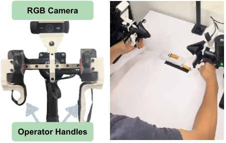

Fig. 3: Hardware Setup. Our printed handles allow for easy operation and data collection.

Chú thích hình · tiếng Việt

Cấu hình phần cứng. Tay cầm in được thiết kế để vận hành và thu dữ liệu thuận tiện.

Hình 3 · Bằng chứng

### Cụ thể hóa thiết kế

**Vai trò logic**

Hình ảnh cho thấy vị trí camera và tay cầm mà mô tả phần cứng dựa vào.

**Thủ pháp / điểm cần xét**

Hình minh họa không thay thế thí nghiệm định lượng công thái học hay đánh giá an toàn.

IV

## Data Processing, Policy Learning & Deployment Xử lý dữ liệu, học & triển khai

Mặt nạ hình học và chuyển tiếp hành động mượt

§17PDF tr. 4EN → VI

Given a dataset of kinesthetic teaching data for fast and precise manipulation, directly applying imitation learning algorithms fail for two reasons. First, a human operator is present with hands holding the robot end-effectors during data collection, while the robots are alone during the autonomous execution phase after deployment. This creates a visual distribution shift between data collection and deployment. Second, fast movements are less forgiving, as small errors in execution can compound into unrecoverable failures and non-smooth actions can cause instability. The high-speed nature of the manipulation data collected presents a hurdle for learning a reliable policy.

Bản dịch tiếng Việt

Với tập dữ liệu dẫn động trực tiếp cho thao tác nhanh và chính xác, áp dụng thẳng thuật toán học bắt chước có thể thất bại vì hai lý do. Thứ nhất, khi thu dữ liệu, người vận hành giữ đầu công tác nên bàn tay hiện trong ảnh; khi triển khai tự hành, robot hoạt động một mình. Điều này gây khác biệt phân bố thị giác giữa hai giai đoạn. Thứ hai, chuyển động nhanh có dung sai thấp: sai số thực thi nhỏ có thể tích lũy thành thất bại không thể khắc phục, còn hành động thiếu trơn có thể gây mất ổn định. Vì vậy, tính chất tốc độ cao của dữ liệu tạo ra trở ngại cho việc học một chính sách tin cậy.

§17 · Khái niệm

### Phát biểu bài toán của quy trình học

**Vai trò logic**

Tái lập hai giả thuyết sẽ được kiểm nghiệm bằng các thí nghiệm loại bỏ thành phần.

**Thủ pháp / điểm cần xét**

Cách diễn đạt ‘thất bại vì hai lý do’ mạnh hơn kết quả No Mask: một số tác vụ không che vẫn đạt 90–100%. Mặt nạ là cải thiện theo nhiệm vụ, không phải điều kiện bắt buộc tuyệt đối.

§18PDF tr. 4EN → VI

To address the distribution shift between data collection and deployment, we employ a masking technique to align the visual domains for training and testing, illustrated in Fig. 4. By removing regions with human hands and arms appearing in cameras using an analytical model, we align the visual input distributions, preventing the policy from being distracted by the presence or absence of the human operator. And to ensure smooth execution of fast manipulation, we introduce test-time smoothing, a post-hoc real-time processing for smooth transitions between action chunks. Illustrated in Fig. 5, this method helps mitigate the jerkiness at high speed that can arise from action chunking [3], allowing the robot to perform fast motions without sacrificing stability.

Bản dịch tiếng Việt

Để xử lý khác biệt phân bố giữa thu dữ liệu và triển khai, chúng tôi dùng mặt nạ nhằm đồng nhất miền thị giác khi huấn luyện và kiểm tra (Hình 4). Một mô hình giải tích loại bỏ các vùng có bàn tay và cánh tay người trong ảnh, giúp chính sách không bị chi phối bởi việc người vận hành xuất hiện hay biến mất. Để thực hiện thao tác nhanh một cách êm, chúng tôi thêm bước làm trơn tại thời điểm chạy: xử lý hậu kỳ thời gian thực để chuyển tiếp mượt giữa các đoạn hành động. Như Hình 5, phương pháp giảm hiện tượng giật do phân đoạn hành động [3], cho phép robot chuyển động nhanh mà vẫn ổn định.

§18 · Phương pháp

### Ánh xạ vấn đề sang can thiệp

**Vai trò logic**

Thiết lập cấu trúc song song: lệch miền ↔ mặt nạ; gián đoạn lệnh ↔ làm trơn.

**Thủ pháp / điểm cần xét**

Lập luận cơ chế rõ ràng và có thể kiểm chứng. Tuy nhiên, ‘đồng nhất miền’ chỉ áp dụng cho vùng người được che, không bảo đảm mọi yếu tố thị giác khác đều giống nhau.

§19PDF tr. 4–5EN → VI

Masking in Image Space. During training, we preprocess the collected data, aiming to mask out the appearances of hands and arms of the human operators. Given that the joint positions of both arms and robot description files are known, we can compute the poses of end-effectors of both robot arms in their respective base frames using forward kinematics (FK). We also know the transformation between the base frames of both arms through camera calibration. Thus, we can transform the end-effector pose of one arm into the base frame of the other arm. Since the relative pose of the handles for the human hands is fixed with respect to the end-effector pose, we deterministically calculate the center pose of the left hand in the right camera, and similarly for the right hand in the left camera, and mask out a small square region perpendicular to the end-effector pointing direction near the handles by setting the image RGB values for that region to be zero. For the top camera, we similarly mask out two rectangular regions for both hands and arms based on the end-effector poses. We provide an illustration for masking in Fig. 4. During deployment, we perform masking in real time for every frame. Formally, at each time step t, we perform the masking operation M and get three processed images I′<sub>1,t</sub>, I′<sub>2,t</sub>, I′<sub>3,t</sub>, where I′<sub>1,t</sub>, I′<sub>2,t</sub>, I′<sub>3,t</sub> = M(I<sub>1,t</sub>, I<sub>2,t</sub>, I<sub>3,t</sub>, q<sub>t</sub>, FK).

Bản dịch tiếng Việt

Che mặt nạ trong không gian ảnh. Khi huấn luyện, dữ liệu được tiền xử lý để che bàn tay và cánh tay người vận hành. Vì biết vị trí khớp và tệp mô tả robot, chúng tôi dùng động học thuận (FK) để tính tư thế đầu công tác của hai tay trong hệ tọa độ gốc tương ứng. Phép hiệu chuẩn camera cũng cung cấp biến đổi giữa hai hệ gốc, cho phép biểu diễn đầu công tác của tay này trong hệ của tay kia. Do vị trí tay cầm so với đầu công tác là cố định, có thể xác định tất định tâm bàn tay trái trong camera phải và ngược lại. Sau đó, một vùng vuông nhỏ gần tay cầm, vuông góc với hướng đầu công tác, được che bằng cách đặt các giá trị RGB về 0. Với camera trên cao, hai vùng chữ nhật tương ứng bàn tay và cánh tay được che dựa trên tư thế đầu công tác. Hình 4 minh họa thao tác này. Khi triển khai, mặt nạ được tính theo thời gian thực cho từng khung hình. Tại mỗi thời điểm t, phép M tạo ba ảnh đã xử lý theo công thức: (I′<sub>1,t</sub>, I′<sub>2,t</sub>, I′<sub>3,t</sub>) = M(I<sub>1,t</sub>, I<sub>2,t</sub>, I<sub>3,t</sub>, q<sub>t</sub>, FK).

§19 · Phương pháp

### Trình bày thuật toán mặt nạ có thể tái lập

**Vai trò logic**

Chuyển trực giác ‘bỏ người khỏi ảnh’ thành phép biến đổi hình học dùng được cả khi huấn luyện lẫn triển khai.

**Thủ pháp / điểm cần xét**

Ưu thế là không cần một mô hình phân đoạn học thêm. Điểm yếu là dựa vào hiệu chuẩn, hình học tay cầm và vùng che bảo thủ; vật thể cần thao tác có thể bị che cùng bàn tay.

§20PDF tr. 5EN → VI

Policy Learning. Unlike teleoperation where the action commands for the robots are explicitly sent through devices like leader arms or VR controllers, we only capture the visual and proprioceptive readings from the robots. We aim to train policies that can predict future joint positions which the robots should achieve given current images and proprioception. We follow the recent progress in imitation learning by using action chunking [1], which mitigates compounding error problems that is common in behavior cloning methods and improves overall performance. Given a policy π and an action chunk size of T, we train the policy by maximizing the probability π([q<sub>t+1</sub>, …, q<sub>t+T</sub>] | I′<sub>1,t</sub>, I′<sub>2,t</sub>, I′<sub>3,t</sub>, q<sub>t</sub>), where the predicted future joint positions will serve as the target joint positions for a low-level PD controller to execute. We additionally tune an action lookahead where we skip the first n actions at every chunk boundary, resulting from action delay at execution. In this paper, we use ACT [1] as the policy representation, but we expect other policy representations for imitation learning with action chunks would also work.

Bản dịch tiếng Việt

Học chính sách. Khác với điều khiển từ xa gửi trực tiếp lệnh qua tay dẫn hoặc bộ điều khiển thực tế ảo, chúng tôi chỉ ghi nhận hình ảnh và trạng thái tự cảm nhận của robot. Mục tiêu là huấn luyện chính sách dự đoán các vị trí khớp tương lai mà robot cần đạt từ ảnh và trạng thái hiện tại. Chúng tôi dùng phân đoạn hành động [1], một tiến bộ trong học bắt chước giúp giảm lỗi tích lũy thường gặp ở sao chép hành vi và nâng hiệu năng tổng thể. Với chính sách π và độ dài đoạn T, mô hình được huấn luyện bằng cách cực đại hóa xác suất π([q<sub>t+1</sub>, …, q<sub>t+T</sub>] | I′<sub>1,t</sub>, I′<sub>2,t</sub>, I′<sub>3,t</sub>, q<sub>t</sub>). Các vị trí dự đoán trở thành vị trí đích cho bộ điều khiển PD cấp thấp. Chúng tôi còn điều chỉnh khoảng nhìn trước hành động: bỏ n hành động đầu tại mỗi ranh giới đoạn để bù độ trễ thực thi. Bài báo sử dụng ACT [1] làm biểu diễn chính sách, nhưng kỳ vọng những biểu diễn học bắt chước theo đoạn khác cũng có thể dùng được.

§20 · Phương pháp

### Xác định mục tiêu học và giao diện điều khiển

**Vai trò logic**

Giải thích dữ liệu quan sát được biến thành các lệnh vị trí theo đoạn như thế nào.

**Thủ pháp / điểm cần xét**

ACT là thành phần kế thừa, không phải thuật toán mới của bài. Khả năng chuyển sang họ chính sách khác là kỳ vọng chưa được kiểm nghiệm; giá trị n không được chỉ rõ ở đây.

§21PDF tr. 5EN → VI

Test-Time Smoothing. When moving at increased speeds, we observe that discontinuities between action chunks [3] become larger and more visible, affecting policy performance. We introduce a simple post-hoc test-time smoothing technique. Illustrated in Fig. 5, we tackle the discontinuity between two adjacent chunks by blending the last few actions of a chunk with the first few actions of the later chunk where these two action chunks have a small overlap in corresponding timesteps. For a smoothing window size of H smaller than the action chunk size T, an action chunk [q̂<sup>1</sup><sub>t+1</sub>, …, q̂<sup>1</sup><sub>t+T</sub>] is first predicted at timestep t, and another one [q̂<sup>2</sup><sub>t+T−H+1</sub>, …, q̂<sup>2</sup><sub>t+2T−H</sub>] is later predicted at timestep t + T − H. At timestep t′, the action command a<sub>t′</sub> is the raw predicted target joint position q̂<sub>t′+1</sub> at regions where there is no chunk overlap. Within the overlapping regions, we weigh the two corresponding target joint positions by using a sigmoid coefficient w(t′) = sigmoid((t′ − (t + T − H) − H/2)/σ) where σ is a time scale, and the final blended action command is a<sub>t′</sub> = (1 − w(t′)) × q̂<sup>1</sup><sub>t′+1</sub> + w(t′) × q̂<sup>2</sup><sub>t′+1</sub>.

Bản dịch tiếng Việt

Làm trơn tại thời điểm chạy. Khi tốc độ tăng, sự gián đoạn giữa các đoạn hành động [3] trở nên lớn và rõ hơn, làm giảm hiệu năng. Chúng tôi đưa ra một kỹ thuật hậu xử lý đơn giản: trộn những hành động cuối của đoạn trước với những hành động đầu của đoạn sau tại một vùng chồng lấn thời gian nhỏ (Hình 5). Chọn cửa sổ làm trơn H nhỏ hơn độ dài đoạn T. Đoạn thứ nhất [q̂<sup>1</sup><sub>t+1</sub>, …, q̂<sup>1</sup><sub>t+T</sub>] được dự đoán tại t; đoạn thứ hai [q̂<sup>2</sup><sub>t+T−H+1</sub>, …, q̂<sup>2</sup><sub>t+2T−H</sub>] được dự đoán tại t + T − H. Ngoài vùng chồng lấn, lệnh a<sub>t′</sub> là vị trí khớp đích dự đoán trực tiếp q̂<sub>t′+1</sub>. Trong vùng chồng lấn, hai dự đoán cùng thời điểm được kết hợp bằng trọng số sigmoid w(t′) = sigmoid((t′ − (t + T − H) − H/2)/σ), trong đó σ là thang thời gian. Lệnh cuối cùng là a<sub>t′</sub> = (1 − w(t′)) × q̂<sup>1</sup><sub>t′+1</sub> + w(t′) × q̂<sup>2</sup><sub>t′+1</sub>.

§21 · Phương pháp

### Mô tả đóng góp làm trơn cốt lõi

**Vai trò logic**

Đưa ra cơ chế chuyển dần quyền điều khiển từ dự đoán cũ sang dự đoán mới thay vì ghép đột ngột.

**Thủ pháp / điểm cần xét**

Trộn cục bộ khác với trung bình nhiều đoạn ở mọi thời điểm. Công thức là cơ chế làm trơn thực dụng, không phải chứng minh ổn định động lực học hay bảo đảm giới hạn gia tốc/mô-men.

§22PDF tr. 5EN → VI

By adjusting the smoothing horizon and time scale of the sigmoid coefficient, we can adjust how sharply and reactively the robot will change to follow a later action chunk from a previous obsolete action chunk.

Bản dịch tiếng Việt

Bằng cách điều chỉnh độ dài cửa sổ làm trơn và thang thời gian của trọng số sigmoid, chúng tôi có thể thay đổi độ gắt và mức độ phản ứng khi robot chuyển từ đoạn hành động cũ đã lỗi thời sang đoạn dự đoán mới.

§22 · Phương pháp

### Giải thích đánh đổi tham số

**Vai trò logic**

Thừa nhận làm trơn phải cân bằng tính liên tục với khả năng phản ứng trước quan sát mới.

**Thủ pháp / điểm cần xét**

Thiếu khảo sát độ nhạy hoặc giá trị H và σ cụ thể trong các bảng cấu hình. Vì thế, tái lập chính xác chất lượng chuyển tiếp vẫn cần thêm thông tin triển khai.

[figure not shown]

Fig. 4: Masking. Our masking method adjusts in real time based on the position of the end effectors of both arms.

Chú thích hình · tiếng Việt

Mặt nạ. Phương pháp điều chỉnh theo thời gian thực dựa vào vị trí đầu công tác của cả hai tay máy.

Hình 4 · Bằng chứng

### Minh họa mặt nạ động

**Vai trò logic**

Cho thấy vùng bị che đi theo hình học robot, không phải mặt nạ ảnh tĩnh.

**Thủ pháp / điểm cần xét**

Vùng che có thể bỏ cả dấu hiệu quan trọng của vật thể, như tác giả thừa nhận ở kết luận.

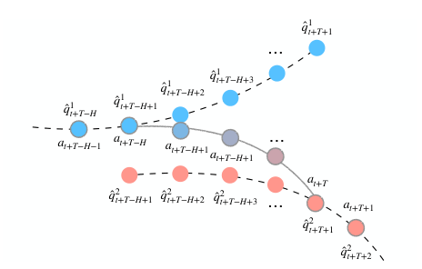

Fig. 5: Test-Time Smoothing. Given a previous chunk of target joint positions ˆq1 and a later chunk ˆq2, we apply smoothing to obtain the final commanded actions a.

Chú thích hình · tiếng Việt

Làm trơn tại thời điểm chạy. Từ đoạn vị trí khớp đích trước q̂¹ và đoạn sau q̂², phép làm trơn tạo chuỗi lệnh cuối cùng a.

Hình 5 · Bằng chứng

### Minh họa trộn hai đoạn

**Vai trò logic**

Liên kết công thức sigmoid với chuyển tiếp cục bộ giữa hai dự đoán.

**Thủ pháp / điểm cần xét**

Đây là sơ đồ nguyên lý, không phải quỹ đạo thực đo hoặc chứng minh bảo đảm ổn định.

V

## Experiments Thực nghiệm

Kiểm tra cơ chế, hiệu năng và trải nghiệm vận hành

§23PDF tr. 5EN → VI

In our experiments, we aim to determine the extent to which our masking strategy as well as our smoothing method benefit the overall success rate of policies. Additionally, we study the effects of several comparative approaches in these two domains. Through user trials, we verify the intuitive understanding that our directly operated data collection platform enables faster training of human operators. All main tasks are shown in Fig. 1.

Bản dịch tiếng Việt

Trong các thí nghiệm, chúng tôi đánh giá mức đóng góp của chiến lược mặt nạ và phương pháp làm trơn vào tỷ lệ thành công chung của chính sách. Chúng tôi cũng so sánh một số cách tiếp cận khác trong hai nhóm này. Thông qua thử nghiệm với người dùng, chúng tôi kiểm tra nhận định trực quan rằng nền tảng thu dữ liệu được vận hành trực tiếp giúp người vận hành học cách sử dụng nhanh hơn. Các nhiệm vụ chính được minh họa trong Hình 1.

§23 · Phương pháp

### Đặt câu hỏi đánh giá thực nghiệm

**Vai trò logic**

Chuyển từ cơ chế đề xuất sang ba nhóm bằng chứng: loại bỏ thành phần, tốc độ và khả năng học của người vận hành.

**Thủ pháp / điểm cần xét**

Cần phân biệt hiệu năng chính sách tự hành với thời gian thao tác của người dùng. Hai nhóm thí nghiệm hỗ trợ những mệnh đề khác nhau.

V.A

## Tasks Các nhiệm vụ

Năm phép thử cho phối hợp, tiếp xúc và động lực học

§24PDF tr. 5EN → VI

In Unstack Cups, the left arm reaches out and grasps the bottom of two stacked red solo cups. Then, the right arm subsequently grasps the lip of the top cup without contacting the bottom, and pulls. The grippers must carefully balance their grasps; if the left grips too hard, the right can’t tilt and grab. If the right over-grips, it pulls the entire stack. The cups’ initial starting positions are randomized along a fifteen centimeter piece of tape. This task is collected with a timer of four seconds.

Bản dịch tiếng Việt

Tách cốc. Tay trái vươn tới và nắm phần đáy của hai cốc nhựa đỏ đang chồng nhau. Tay phải nắm vành cốc trên mà không chạm cốc dưới rồi kéo ra. Hai bộ kẹp phải phối hợp lực nắm cẩn thận: nếu tay trái bóp quá mạnh, tay phải không thể nghiêng để nắm; nếu tay phải bóp quá chặt, nó sẽ kéo cả chồng cốc. Vị trí ban đầu của cốc được ngẫu nhiên hóa dọc một đoạn băng dính dài 15 cm. Dữ liệu nhiệm vụ được thu với giới hạn thời gian bốn giây.

§24 · Phương pháp

### Vận hành hóa bài kiểm tra độ chính xác

**Vai trò logic**

Dùng một thao tác nhạy với lực nắm để kiểm tra liệu tốc độ có làm mất độ chính xác hay không.

**Thủ pháp / điểm cần xét**

Ngẫu nhiên hóa vị trí giúp tránh chỉ học một tọa độ, nhưng phạm vi 15 cm và cùng loại cốc chưa chứng minh khái quát sang vật thể hoặc bối cảnh mới.

§25PDF tr. 5–6EN → VI

Battery Insertion. During execution, one arm picks up a battery and places it at an oblique angle into a remote control, taking care not to touch the spring. It then pushes one end of the battery into the spring. The other gripper then raises and forcefully pushes down on the battery, slotting it into place. The battery and the remote are randomized along the tape. This task is collected in under seven seconds.

Bản dịch tiếng Việt

Lắp pin. Một tay nhặt pin rồi đặt nghiêng vào điều khiển từ xa, tránh chạm lò xo. Sau đó, nó đẩy một đầu pin vào lò xo. Bộ kẹp còn lại nâng lên và ấn mạnh xuống pin để đưa pin vào đúng khe. Pin và điều khiển được ngẫu nhiên hóa vị trí dọc đoạn băng dính. Dữ liệu nhiệm vụ được thu trong dưới bảy giây.

§25 · Phương pháp

### Đưa vào tác vụ tiếp xúc cần lực

**Vai trò logic**

Kiểm tra độ chính xác và phối hợp hai tay trong thao tác có ràng buộc tiếp xúc.

**Thủ pháp / điểm cần xét**

Đây là tác vụ phân biệt rõ các phương pháp trong Bảng I–III. Tuy nhiên, thành công không có nghĩa hệ thống đã học biểu diễn lực hay điều khiển xúc giác tường minh.

§26PDF tr. 6EN → VI

Bus Table involves removing common dining ware from a pan and placing them into a tray. An arm first grasps a nearby tray and brings it closer to the pan. Then, both arms engage, alternating picking up and placing four items from the pan into the tray: a cup, a bowl, a spoon, and a plate. The position of the pan is randomized along the tape. This task is collected with a timer of six seconds.

Bản dịch tiếng Việt

Dọn bàn. Robot lấy các vật dụng ăn uống thông thường ra khỏi một chiếc chảo và đặt vào khay. Trước hết, một tay nắm khay gần đó rồi kéo tới gần chảo. Tiếp theo, hai tay luân phiên gắp và chuyển bốn vật từ chảo sang khay: cốc, bát, thìa và đĩa. Vị trí chảo được ngẫu nhiên hóa dọc đoạn băng dính. Dữ liệu được thu với giới hạn sáu giây.

§26 · Phương pháp

### Kiểm tra chuỗi thao tác hai tay

**Vai trò logic**

Bổ sung tác vụ có nhiều lần gắp–đặt và biên độ chuyển động lớn.

**Thủ pháp / điểm cần xét**

Không nên đồng nhất ‘dọn bàn’ trong bài với dọn mọi loại bàn ăn: bài kiểm tra có bốn vật dụng xác định, bố cục được kiểm soát và khoảng biến thiên giới hạn.

§27PDF tr. 6EN → VI

Fold Shorts involves folding a pair of shorts placed flat. The arms must reach and grasp the edge of the bottom trunk of the shorts and toss the trunk over from bottom to top flush against the top cover. Then, the left gripper must grasp the edge of the shorts along the waist, and toss it from left to right while the right arm creates a crease. The shorts are randomly rotated by up to thirty degrees in their initial position, and this task is collected against a timer of five seconds.

Bản dịch tiếng Việt

Gấp quần đùi. Quần được đặt phẳng. Hai tay vươn tới nắm mép phần dưới của quần rồi hất từ dưới lên trên, sao cho áp sát phần trên. Sau đó, tay trái nắm mép ở cạp quần và hất từ trái sang phải, trong khi tay phải tạo nếp gấp. Góc đặt ban đầu của quần được ngẫu nhiên hóa trong phạm vi 30 độ. Dữ liệu được thu với giới hạn năm giây.

§27 · Phương pháp

### Mở rộng kiểm tra sang vật biến dạng

**Vai trò logic**

Cho thấy quy trình không chỉ áp dụng cho vật cứng hay chuyển động gần tĩnh.

**Thủ pháp / điểm cần xét**

Chỉ thay đổi góc ban đầu của một loại quần chưa chứng minh khái quát sang chất liệu, kích thước hoặc trạng thái vải khác. Thời gian thu mẫu 5 giây khác thời gian chính sách 5,94 giây.

§28PDF tr. 6EN → VI

Toss & Catch. The left arm first approaches and picks up a small soft ball on the table. Then it swings forward and up dynamically in high speed while releasing the ball. The right arm approaches the tossed ball-in-air swiftly with closing grippers to catch the ball. The task is only two seconds long.

Bản dịch tiếng Việt

Tung và bắt bóng. Tay trái tiến tới nhặt một quả bóng mềm nhỏ trên bàn, sau đó vung nhanh về trước và lên trên đồng thời thả bóng. Tay phải nhanh chóng đưa bộ kẹp tới quả bóng đang bay và khép lại để bắt. Toàn bộ nhiệm vụ chỉ dài hai giây.

§28 · Phương pháp

### Đặt bài kiểm tra động lực học cao

**Vai trò logic**

Tạo trường hợp mà chậm lại hoặc làm mẫu từ xa trở nên đặc biệt khó.

**Thủ pháp / điểm cần xét**

Đây là minh chứng năng lực nổi bật, song không có baseline puppeteering hoàn thành để so sánh định lượng. Nhiệm vụ này dùng HESSIAN thay vì ARX.

V.B

## Comparisons Các đối chứng

Bảy baseline trả lời những câu hỏi khác nhau

§29PDF tr. 6EN → VI

We compare our method to Inpainting, No Mask, Temporal Ensembling (TE), No Smooth, Puppeteering, Puppet Double Freq, and Puppet Skip Actions.

Bản dịch tiếng Việt

Chúng tôi so sánh phương pháp đề xuất với Inpainting, No Mask, Temporal Ensembling (TE), No Smooth, Puppeteering, Puppet Double Freq và Puppet Skip Actions.

§29 · Phương pháp

### Liệt kê các đối chứng

**Vai trò logic**

Tách câu hỏi thị giác, làm trơn và tăng tốc dữ liệu chậm thành những so sánh riêng.

**Thủ pháp / điểm cần xét**

Các baseline không tạo thành một thí nghiệm nhân tố đầy đủ; không thể suy ra mọi tương tác giữa mặt nạ, làm trơn và phần cứng từ danh sách này.

§30PDF tr. 6EN → VI

Inpainting [57]. A policy trained on diffusion inpainted video, where the operator hands are segmented and replaced with the background by a pretrained segmentation [58] and pretrained diffusion network [59].

Bản dịch tiếng Việt

Inpainting [57]. Chính sách được huấn luyện từ video đã được điền nền bằng mô hình khuếch tán: bàn tay người vận hành được phân đoạn và thay bằng nền nhờ một mô hình phân đoạn huấn luyện sẵn [58] cùng một mạng khuếch tán huấn luyện sẵn [59].

§30 · Phương pháp

### Định nghĩa đối chứng xóa người bằng sinh ảnh

**Vai trò logic**

So sánh mặt nạ hình học đơn giản với một phương pháp tái tạo hình ảnh phức tạp hơn.

**Thủ pháp / điểm cần xét**

Kết quả chỉ phản ánh chuỗi inpainting cụ thể đã dùng, không bác bỏ mọi phương pháp xóa người bằng mô hình sinh.

§31PDF tr. 6EN → VI

No Mask. A policy trained with the raw video.

Bản dịch tiếng Việt

No Mask. Chính sách được huấn luyện trực tiếp trên video gốc, không che mặt nạ.

§31 · Phương pháp

### Định nghĩa đối chứng không xử lý hình ảnh

**Vai trò logic**

Cô lập lợi ích tăng thêm của việc che người vận hành.

**Thủ pháp / điểm cần xét**

Đây là đối chứng thiết yếu để phân biệt ‘cần mặt nạ mới hoạt động’ với ‘mặt nạ cải thiện một số nhiệm vụ’.

§32PDF tr. 6EN → VI

Temporal Ensembling [1]. A post-process smoothing method where an action chunk is predicted every timestep, and exponentially weighted and averaged with past action chunks.

Bản dịch tiếng Việt

Temporal Ensembling [1]. Đây là phương pháp làm trơn hậu xử lý: ở mỗi bước thời gian, một đoạn hành động được dự đoán rồi lấy trung bình với các đoạn quá khứ theo trọng số suy giảm hàm mũ.

§32 · Phương pháp

### Định nghĩa đối chứng làm trơn theo thời gian

**Vai trò logic**

Đặt làm trơn cục bộ của bài bên cạnh phương pháp đã có trong ACT.

**Thủ pháp / điểm cần xét**

Suy luận ở mọi bước làm thay đổi cả chi phí tính toán lẫn cách kết hợp dự đoán; kết quả thực nghiệm không tách hoàn toàn hai ảnh hưởng này.

§33PDF tr. 6EN → VI

No Smooth. No smoothing method applied.

Bản dịch tiếng Việt

No Smooth. Không áp dụng bất kỳ phương pháp làm trơn nào.

§33 · Phương pháp

### Định nghĩa đối chứng bỏ làm trơn

**Vai trò logic**

Đo tác động trực tiếp của bước xử lý ranh giới đoạn.

**Thủ pháp / điểm cần xét**

Nếu độ chính xác giảm trong cùng cấu hình dữ liệu và chính sách, đây là bằng chứng gần nhất cho giá trị thực tiễn của làm trơn.

§34PDF tr. 6EN → VI

Puppeteering [1]. The operator collects and deploys policies on a teleoperated setup.

Bản dịch tiếng Việt

Puppeteering [1]. Người vận hành thu thập dữ liệu và triển khai chính sách trên một hệ thống điều khiển từ xa bằng tay dẫn–tay theo.

§34 · Phương pháp

### Định nghĩa đối chứng hệ thống

**Vai trò logic**

Làm mốc so sánh tốc độ với quy trình thu mẫu bằng tay dẫn.

**Thủ pháp / điểm cần xét**

Phụ lục III xác định đây là ALOHA 2. So sánh hệ thống thực tiễn hữu ích, nhưng khác nền tảng robot làm yếu diễn giải nhân quả riêng về giao diện.

§35PDF tr. 6EN → VI

Puppet Double Freq. On the puppeteering setup, the policy is deployed with double the controller frequency.

Bản dịch tiếng Việt

Puppet Double Freq. Trên hệ thống tay dẫn–tay theo, chính sách được triển khai với tần số bộ điều khiển tăng gấp đôi.

§35 · Phương pháp

### Định nghĩa cách tăng tốc thứ nhất

**Vai trò logic**

Kiểm tra giả thuyết dữ liệu chậm có thể tăng tốc đơn giản bằng thay đổi nhịp thực thi.

**Thủ pháp / điểm cần xét**

Đây chỉ là một baseline tăng tốc trực tiếp, không đại diện cho mọi phương pháp tăng tốc có tối ưu động lực học hoặc tinh chỉnh.

§36PDF tr. 6EN → VI

Puppet Skip Actions. On the puppeteering setup, the policy acts on every other predicted action per chunk.

Bản dịch tiếng Việt

Puppet Skip Actions. Trên hệ thống tay dẫn–tay theo, trong mỗi đoạn hành động, chính sách chỉ thực hiện một hành động rồi bỏ qua hành động kế tiếp, luân phiên như vậy.

§36 · Phương pháp

### Định nghĩa cách tăng tốc thứ hai

**Vai trò logic**

Kiểm tra một cách nén thời gian mà vẫn giữ tần số bộ điều khiển.

**Thủ pháp / điểm cần xét**

Bỏ cách quãng có thể bỏ đúng bước tiếp xúc quan trọng. Đây là hạn chế cấu trúc của baseline, không chứng minh mọi kỹ thuật lấy thưa dữ liệu đều kém.

V.C

## Masking Aligns Data Collection and Deployment Hiệu quả của mặt nạ

Đối chiếu No Mask, Inpainting và Ours

§37PDF tr. 6EN → VI

We evaluate the efficacy of masking, which aligns the visual distribution of the policy between collection and deployment time. Table I details the results of our experimental trials comparing policies trained with masking, no masking, and on diffusion inpainted video. We note an increase in performance on most tasks with masking compared to simply training with hands included and inpainted video.

Bản dịch tiếng Việt

Chúng tôi đánh giá hiệu quả của mặt nạ trong việc đồng nhất phân bố hình ảnh mà chính sách gặp khi thu dữ liệu và triển khai. Bảng I trình bày thử nghiệm các chính sách học từ ảnh có mặt nạ, ảnh không che và video được điền nền bằng mô hình khuếch tán. Ở phần lớn nhiệm vụ, mặt nạ cải thiện hiệu năng so với huấn luyện với bàn tay còn trong ảnh hoặc với video đã điền nền.

§37 · Bằng chứng

### Đưa bằng chứng cho thành phần thị giác

**Vai trò logic**

Kiểm nghiệm can thiệp mặt nạ bằng các chính sách có xử lý ảnh khác nhau.

**Thủ pháp / điểm cần xét**

Tỷ lệ thành công toàn nhiệm vụ: tách cốc 90/85/90%, lắp pin 75/65/85%, dọn bàn 100/100/100%, gấp quần 90/80/100% (No Mask/Inpainting/Ours). Có cải thiện và hòa, không phải thắng tuyệt đối; bảng không kèm khoảng tin cậy.

§38PDF tr. 6EN → VI

The policies trained on inpainted video suffer significant performance losses compared to the base video. We hypothesize that this is due to two factors. First, as can be seen in Fig. 6, the shadows of the arms are still visible against the reflective surface of the table. Another factor is the noisy diffusing of frames due to lack of context. These visual artifacts not visible at test time may confuse the policy. Given a more controlled environment, this method’s performance may improve.

Bản dịch tiếng Việt

Các chính sách huấn luyện trên video điền nền suy giảm hiệu năng đáng kể so với video gốc. Chúng tôi giả thuyết có hai nguyên nhân. Thứ nhất, như Hình 6, bóng cánh tay vẫn xuất hiện trên mặt bàn phản chiếu. Thứ hai, quá trình khuếch tán tạo nhiễu giữa các khung hình do thiếu ngữ cảnh. Những giả ảnh không có khi kiểm tra này có thể làm chính sách nhầm lẫn. Trong một môi trường được kiểm soát tốt hơn, hiệu quả của phương pháp này có thể tăng lên.

§38 · Nhượng bộ / phản biện

### Giải thích thất bại đối chứng và nhượng bộ

**Vai trò logic**

Tách nguyên nhân khả dĩ của kết quả inpainting khỏi kết luận về mặt nạ đề xuất.

**Thủ pháp / điểm cần xét**

Tác giả dùng đúng cấp độ ‘giả thuyết’. Hình ảnh minh họa gợi cơ chế nhưng không cô lập tác động của bóng và nhiễu; Bảng I còn cho thấy dọn bàn hòa 100%.

Bảng I · Toàn bộ số liệu

**TABLE I:** Our masking improves performance. Our masking strategy almost uniformly beats non-masked and diffusion inpainted in policies, enabling tasks such as battery insertion.

Chú thích bảng · tiếng Việt

Mặt nạ cải thiện hiệu năng. Tác giả cho rằng chiến lược mặt nạ hầu như luôn vượt chính sách không che và chính sách học từ video điền nền bằng khuếch tán, hỗ trợ các tác vụ như lắp pin.

Bảng I–III: các cột thành công tính theo %; Time tính theo giây. Có thể cuộn ngang từng bảng trên màn hình nhỏ. C&S, B&P giữ ký hiệu gốc.

Unstack Cups · Tách cốc

| Method / Hạng mục | Grab · Nắm | Pull · Kéo | Whole · Toàn bộ | Time · Giây |
| --- | --- | --- | --- | --- |
| No Mask | 90 | 90 | 90 | 4.12 |
| Inpainting | 100 | 85 | 85 | 3.92 |
| Ours | 100 | 90 | 90 | 3.97 |

Battery Insertion · Lắp pin

| Method / Hạng mục | Pick · Nhặt | Place · Đặt | Prepare · Chuẩn bị | Push · Ấn | Whole · Toàn bộ | Time · Giây |
| --- | --- | --- | --- | --- | --- | --- |
| No Mask | 95 | 95 | 85 | 75 | 75 | 6.44 |
| Inpainting | 95 | 95 | 70 | 65 | 65 | 5.65 |
| Ours | 100 | 100 | 90 | 85 | 85 | 5.70 |

Bus Table · Dọn bàn

| Method / Hạng mục | C&S | B&P | Whole · Toàn bộ | Time · Giây |
| --- | --- | --- | --- | --- |
| No Mask | 100 | 100 | 100 | 6.97 |
| Inpainting | 100 | 100 | 100 | 6.57 |
| Ours | 100 | 100 | 100 | 6.81 |

Fold Shorts · Gấp quần

| Method / Hạng mục | Up · Gấp lên | Right · Gấp phải | Whole · Toàn bộ | Time · Giây |
| --- | --- | --- | --- | --- |
| No Mask | 100 | 90 | 90 | 6.19 |
| Inpainting | 100 | 80 | 80 | 6.20 |
| Ours | 100 | 100 | 100 | 5.94 |

Bảng I · Bằng chứng

### Đọc Bảng I

**Vai trò logic**

Giữ cả kết quả trung gian, thành công toàn nhiệm vụ và thời gian để tránh chọn số có lợi.

**Thủ pháp / điểm cần xét**

Bảng I cho thấy mặt nạ cải thiện hoặc giữ nguyên thành công toàn nhiệm vụ; không nhanh nhất ở mọi trường hợp. Các tỷ lệ là phần trăm; thời gian là giây. C&S và B&P được giữ nguyên vì bảng nguồn không khai triển rõ tên viết tắt.

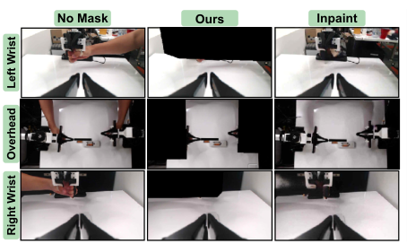

Fig. 6: Masking Comparisons. We show the same initial starting frame of Battery Insertion. Our masking method completely aligns the visual distributions of training and test times. Inpainting via diffusion creates unwanted artifacts.

Chú thích hình · tiếng Việt

So sánh mặt nạ. Cùng khung hình ban đầu của nhiệm vụ lắp pin. Tác giả cho rằng mặt nạ đồng nhất hoàn toàn phân bố thị giác giữa huấn luyện và kiểm tra, còn điền nền bằng khuếch tán tạo giả ảnh không mong muốn.

Hình 6 · Bằng chứng

### Đối chiếu đầu vào thị giác

**Vai trò logic**

Bổ trợ giải thích vì sao che đơn giản có thể tốt hơn tái tạo nền.

**Thủ pháp / điểm cần xét**

‘Đồng nhất hoàn toàn’ là phát biểu của tác giả: ảnh mẫu chỉ minh họa các vùng có người, không chứng minh hai phân bố ảnh hoàn toàn bằng nhau.

V.D

## Test-Time Smoothing Improves Performance Hiệu quả của làm trơn

Thành công cao hơn không luôn có nghĩa nhanh nhất

§39PDF tr. 6EN → VI

In Table II, we see performance comparisons between non-smoothed, test-time smoothed, and temporal ensembling-smoothed trajectories. In all tasks, test-time smoothing achieves the best performance, and by a wide margin in tasks Unstack Cups and Battery Insertion. The resulting instabilities in the high speed non-smoothed policy rollouts result in imprecise grasps and pushes, and while the temporal-ensembling smoothed policies have mixed results, their execution speeds drop in half dramatically from collection time. This is due to the increased processing time necessary to compute inference every timestep.

Bản dịch tiếng Việt

Bảng II so sánh các quỹ đạo không làm trơn, làm trơn tại thời điểm chạy và làm trơn bằng tổng hợp theo thời gian. Ở tất cả các nhiệm vụ, phương pháp đề xuất đạt hiệu năng tốt nhất; chênh lệch đặc biệt lớn ở tách cốc và lắp pin. Chính sách tốc độ cao không làm trơn bị mất ổn định, dẫn đến nắm và đẩy thiếu chính xác. Chính sách tổng hợp theo thời gian cho kết quả không đồng nhất, trong khi tốc độ thực thi giảm mạnh, chỉ còn khoảng một nửa tốc độ thu dữ liệu. Nguyên nhân được nêu là chi phí xử lý tăng do phải suy luận ở từng bước thời gian.

§39 · Bằng chứng

### Kiểm nghiệm tác động làm trơn

**Vai trò logic**

Dùng đồng thời độ thành công và thời gian để đánh giá đánh đổi chính xác–tốc độ.

**Thủ pháp / điểm cần xét**

So với No Smooth, Ours tăng thành công tách cốc 65→90%, pin 75→85%, dọn bàn 80→100%, gấp quần 80→100%. Ours không luôn nhanh nhất: lắp pin 5,70 s so với 5,29 s. ‘Tốt nhất’ cần hiểu là thành công, với trường hợp hòa TE ở dọn bàn.

§40PDF tr. 6–7EN → VI

A failure mode of temporal ensembling is its tendency to choose an averaged path when forced to change course [3]. We hypothesize that, at higher speeds, the tracking of robot controllers often become less reliable which forces policies to react and frequently change course to adjust for error. Thus, even if temporal ensembling were run on faster hardware and had no inference delay, it would perform even more poorly at speed due to this phenomenon. This also partially explains the presence of discontinuities in the first place, even in relatively uni-modal data with little strategy-switching.

Bản dịch tiếng Việt

Một kiểu thất bại của tổng hợp theo thời gian là chọn đường đi trung bình khi cần đổi hướng [3]. Chúng tôi giả thuyết rằng ở tốc độ cao, khả năng bám của bộ điều khiển robot thường kém tin cậy hơn, buộc chính sách phải phản ứng và thường xuyên đổi hướng để sửa sai. Vì vậy, ngay cả nếu chạy tổng hợp theo thời gian trên phần cứng nhanh hơn và không còn trễ suy luận, nó vẫn có thể hoạt động tệ hơn nữa ở tốc độ cao do hiện tượng này. Cơ chế đó cũng giải thích một phần vì sao xuất hiện gián đoạn giữa các đoạn, ngay cả khi dữ liệu tương đối đơn đỉnh và ít đổi chiến lược.

§40 · Nhượng bộ / phản biện

### Dự đoán phản biện về phần cứng suy luận

**Vai trò logic**

Đáp trước phản biện ‘TE chậm chỉ vì máy tính chưa đủ nhanh’ bằng một cơ chế khác.

**Thủ pháp / điểm cần xét**

Phần TE không trễ và còn kém hơn chưa được thử nghiệm trong bài. Đây là suy luận cơ chế có điều kiện, không nên gộp vào các kết quả đã được chứng minh bằng Bảng II.

Bảng II · Toàn bộ số liệu

**TABLE II:** Smoothing improves performance. Test time smoothing outperforms or matches other methods in success rate in every category.

Chú thích bảng · tiếng Việt

Làm trơn cải thiện hiệu năng. Làm trơn tại thời điểm chạy vượt hoặc ngang các phương pháp khác về tỷ lệ thành công trong mọi hạng mục.

Bảng I–III: các cột thành công tính theo %; Time tính theo giây. Có thể cuộn ngang từng bảng trên màn hình nhỏ. C&S, B&P giữ ký hiệu gốc.

Unstack Cups · Tách cốc

| Method / Hạng mục | Grab · Nắm | Pull · Kéo | Whole · Toàn bộ | Time · Giây |
| --- | --- | --- | --- | --- |
| No Smooth | 100 | 65 | 65 | 4.23 |
| TE | 95 | 35 | 35 | 7.75 |
| Ours | 100 | 90 | 90 | 3.97 |

Battery Insertion · Lắp pin

| Method / Hạng mục | Pick · Nhặt | Place · Đặt | Prepare · Chuẩn bị | Push · Ấn | Whole · Toàn bộ | Time · Giây |
| --- | --- | --- | --- | --- | --- | --- |
| No Smooth | 100 | 85 | 75 | 75 | 75 | 5.29 |
| TE | 100 | 100 | 85 | 55 | 55 | 10.18 |
| Ours | 100 | 100 | 90 | 85 | 85 | 5.70 |

Bus Table · Dọn bàn

| Method / Hạng mục | C&S | B&P | Whole · Toàn bộ | Time · Giây |
| --- | --- | --- | --- | --- |
| No Smooth | 100 | 80 | 80 | 6.70 |
| TE | 100 | 100 | 100 | 12.23 |
| Ours | 100 | 100 | 100 | 6.81 |

Fold Shorts · Gấp quần

| Method / Hạng mục | Up · Gấp lên | Right · Gấp phải | Whole · Toàn bộ | Time · Giây |
| --- | --- | --- | --- | --- |
| No Smooth | 95 | 80 | 80 | 6.16 |
| TE | 100 | 90 | 90 | 11.60 |
| Ours | 100 | 100 | 100 | 5.94 |

Bảng II · Bằng chứng

### Đọc Bảng II

**Vai trò logic**

Giữ cả kết quả trung gian, thành công toàn nhiệm vụ và thời gian để tránh chọn số có lợi.

**Thủ pháp / điểm cần xét**

Bằng chứng mạnh nhất cho bước làm trơn là cải thiện thành công so với No Smooth trên cả bốn tác vụ. Đánh đổi rõ ở lắp pin: 85% trong 5,70 s so với 75% trong 5,29 s. TE hòa 100% với Ours ở dọn bàn nhưng mất 12,23 s.

V.E

## Speed Comparisons So sánh tốc độ

Thu mẫu nhanh hay tăng tốc chính sách từ dữ liệu chậm?

§41PDF tr. 7EN → VI

In this experiment, we investigate the effectiveness of training a policy on slow data, collected with puppeteering on an ALOHA 2 (setup in Appendix III). We artificially increase the policy execution speed in two different ways across three different tasks: Bus Table, Unstack Cups, and Battery Insertion. We are unable to complete the Toss & Catch task with puppeteering due to the difficulty of catching a dynamic object through teleoperation. The results are visible in Table III, where we see sharp drops in performance after speeding up data collected through puppeteering to match the speed of ours. Refer to Appendix IV for chunk boundary jump details.

Bản dịch tiếng Việt

Trong thí nghiệm này, chúng tôi xem xét hiệu quả của chính sách học từ dữ liệu chậm, được thu bằng tay dẫn–tay theo trên ALOHA 2 (cấu hình ở Phụ lục III). Chúng tôi chủ động tăng tốc thực thi theo hai cách trên ba nhiệm vụ: dọn bàn, tách cốc và lắp pin. Không thể hoàn thành nhiệm vụ tung–bắt bóng bằng cách làm mẫu này vì điều khiển từ xa để bắt vật đang chuyển động quá khó. Bảng III cho thấy hiệu năng giảm mạnh khi tăng tốc dữ liệu tay dẫn để tiến gần tốc độ hệ thống đề xuất. Phụ lục IV trình bày chi tiết bước nhảy tại ranh giới đoạn.

§41 · Bằng chứng

### Kiểm tra giải pháp thay thế ‘tăng tốc sau’

**Vai trò logic**

Bổ sung bằng chứng rằng thu dữ liệu nhanh ngay từ đầu có giá trị thực tiễn hơn hai cách tăng tốc đơn giản.

**Thủ pháp / điểm cần xét**

Ngay cả các baseline tăng tốc vẫn chậm hơn Ours. Khác phần cứng và cách thu dữ liệu khiến đây là so sánh toàn hệ thống, không phải thí nghiệm cô lập chỉ một biến tốc độ dữ liệu.

§42PDF tr. 7EN → VI

Puppet Double Freq simply doubles the controller frequency at execution time. This results in policies that appear out of control, with large jumps at chunk boundaries. With actions that jump larger distances, such as in Bus Table, this effect becomes more noticeable. Despite still moving slower than our method, double-timed policies from puppeteering have significantly larger discontinuities than in our method. We hypothesize that these discontinuities lead to deviations between collection and test time, further worsening performance.

Bản dịch tiếng Việt

Puppet Double Freq chỉ tăng gấp đôi tần số bộ điều khiển khi thực thi. Các chính sách khi đó có vẻ mất kiểm soát, với bước nhảy lớn ở ranh giới đoạn. Ảnh hưởng rõ hơn ở những hành động có quãng dịch chuyển lớn như dọn bàn. Dù vẫn chậm hơn phương pháp đề xuất, chính sách tay dẫn chạy gấp đôi nhịp có gián đoạn lớn hơn đáng kể. Chúng tôi giả thuyết các gián đoạn này làm tăng sai khác giữa thu dữ liệu và kiểm tra, từ đó tiếp tục giảm hiệu năng.

§42 · Bằng chứng

### Phân tích thất bại khi tăng tần số

**Vai trò logic**

Nối sự suy giảm độ thành công với chỉ dấu cơ học ở ranh giới đoạn.

**Thủ pháp / điểm cần xét**

Phụ lục IV hỗ trợ việc bước nhảy tăng khoảng 3–3,5 lần. Nhưng quan hệ bước nhảy → thất bại vẫn chưa được cô lập bằng can thiệp chỉ làm thay đổi bước nhảy.

§43PDF tr. 7EN → VI

Puppet Skip Actions is running the controller frequency at the same rate, but skipping every other action. This method introduces less discontinuity, but creates new failure modes such as oscillating above the battery instead of pushing it in, and missing grasps. This is due to the policy oftentimes skipping critical steps, which also reduces overall performance.

Bản dịch tiếng Việt

Puppet Skip Actions giữ nguyên tần số bộ điều khiển nhưng bỏ qua mỗi hành động xen kẽ. Cách này tạo ít gián đoạn hơn, song xuất hiện kiểu lỗi mới như dao động phía trên pin thay vì ấn pin vào, hoặc nắm hụt. Do chính sách thường bỏ qua những bước then chốt, hiệu năng chung cũng giảm.

§43 · Bằng chứng

### Phân tích thất bại khi bỏ hành động

**Vai trò logic**

Cho thấy giảm bước nhảy chưa đủ nếu làm mất các bước quan trọng trong chuỗi tiếp xúc.

**Thủ pháp / điểm cần xét**

Những ví dụ lỗi hỗ trợ cách giải thích định tính; bài không định lượng bao nhiêu thất bại là do bỏ bước so với sai số điều khiển khác.

Bảng III · Toàn bộ số liệu

**TABLE III:** Speed Comparisons. We note a sharp drop in performance on precise tasks when applying either speed-up approach.

Chú thích bảng · tiếng Việt

So sánh tốc độ. Hiệu năng ở các nhiệm vụ cần độ chính xác giảm mạnh khi áp dụng một trong hai cách tăng tốc.

Bảng I–III: các cột thành công tính theo %; Time tính theo giây. Có thể cuộn ngang từng bảng trên màn hình nhỏ. C&S, B&P giữ ký hiệu gốc.

Unstack Cups · Tách cốc

| Method / Hạng mục | Grab · Nắm | Pull · Kéo | Whole · Toàn bộ | Time · Giây |
| --- | --- | --- | --- | --- |
| Puppeteering | 85 | 75 | 75 | 8.84 |
| Puppet Double Freq | 80 | 65 | 65 | 5.47 |
| Puppet Skip Actions | 85 | 50 | 50 | 5.58 |
| Ours | 100 | 90 | 90 | 3.97 |

Battery Insertion · Lắp pin

| Method / Hạng mục | Pick · Nhặt | Place · Đặt | Prep · Chuẩn bị | Push · Ấn | Whole · Toàn bộ | Time · Giây |
| --- | --- | --- | --- | --- | --- | --- |
| Puppeteering | 100 | 90 | 60 | 55 | 55 | 17.87 |
| Puppet Double Freq | 80 | 65 | 35 | 15 | 15 | 12.90 |
| Puppet Skip Actions | 95 | 95 | 55 | 30 | 30 | 10.30 |
| Ours | 100 | 100 | 90 | 85 | 85 | 5.70 |

Bus Table · Dọn bàn

| Method / Hạng mục | C&S | B&P | Whole · Toàn bộ | Time · Giây |
| --- | --- | --- | --- | --- |
| Puppeteering | 100 | 90 | 90 | 16.05 |
| Puppet Double Freq | 95 | 85 | 85 | 9.30 |
| Puppet Skip Actions | 95 | 85 | 85 | 9.29 |
| Ours | 100 | 100 | 100 | 6.81 |

Toss & Catch · Tung–bắt bóng

| Method / Hạng mục | Pick & Toss · Nhặt và tung | Catch · Bắt | Whole · Toàn bộ | Time · Giây |
| --- | --- | --- | --- | --- |
| Puppeteering | — | — | — | — |
| Puppet Double Freq | — | — | — | — |
| Puppet Skip Actions | — | — | — | — |
| Ours | 100 | 80 | 80 | 1.85 |

Bảng III · Bằng chứng

### Đọc Bảng III

**Vai trò logic**

Giữ cả kết quả trung gian, thành công toàn nhiệm vụ và thời gian để tránh chọn số có lợi.

**Thủ pháp / điểm cần xét**

Dấu — là không có kết quả, không phải 0%. Các baseline tăng tốc vẫn chậm hơn Ours. Phép so sánh này dùng hệ thống khác nhau (ALOHA 2 và ARX/HESSIAN), do đó chứng minh lợi thế toàn hệ thống rõ hơn lợi thế nhân quả riêng của giao diện.

V.F

## User Study Nghiên cứu người dùng

Bảy người mới và nhiệm vụ lắp pin

§44PDF tr. 7EN → VI

We conduct a user study with seven volunteers with little to no teleoperation experience, having them operate our setup and puppeteering. For the study, we choose Battery Insertion, a task requiring precision.

Bản dịch tiếng Việt

Chúng tôi tiến hành nghiên cứu với bảy tình nguyện viên có ít hoặc chưa có kinh nghiệm điều khiển từ xa. Họ sử dụng cả hệ thống đề xuất lẫn hệ thống tay dẫn–tay theo. Nhiệm vụ được chọn là lắp pin, một thao tác đòi hỏi độ chính xác.

§44 · Phương pháp

### Xác định mẫu nghiên cứu người dùng

**Vai trò logic**

Kiểm tra trực tiếp lời hứa giao diện dễ học thay vì suy ra từ tỷ lệ thành công của robot.

**Thủ pháp / điểm cần xét**

Bảy người và một nhiệm vụ cho bằng chứng ban đầu. Chưa đủ để khái quát rộng về trình độ, nhân trắc học, mệt mỏi hay mọi loại thao tác.

§45PDF tr. 7EN → VI

In the study, in both setups, users spend three minutes familiarizing themselves with the objects in the scene and the robotic arms. Next, they are shown an expert demonstration and given basic tips on operation procedures. Finally, they are timed in ten trials, attempting to insert the battery into the remote as quickly as possible.

Bản dịch tiếng Việt

Trong cả hai cấu hình, người dùng dành ba phút làm quen với vật thể trong cảnh và các tay robot. Sau đó, họ xem một lượt làm mẫu của chuyên gia và nhận hướng dẫn vận hành cơ bản. Cuối cùng, họ thực hiện mười lượt được bấm giờ, cố gắng lắp pin vào điều khiển nhanh nhất có thể.

§45 · Phương pháp

### Mô tả quy trình nghiên cứu người dùng

**Vai trò logic**

Tạo cơ sở so sánh tốc độ thao tác sau một giai đoạn làm quen ngắn.

**Thủ pháp / điểm cần xét**

Bài không mô tả rõ thứ tự dùng hai hệ thống, hoán đổi thứ tự hay kiểm soát hiệu ứng học chuyển tiếp; đây là các yếu tố có thể ảnh hưởng diễn giải nhân quả.

§46PDF tr. 7EN → VI

We observe in Fig. 7 an ability for users to quickly learn how to operate with our hardware and at speeds up to three times as fast as puppeteering. This primarily results from the operator sitting closer to the environment, giving more direct visual feedback, and haptic sensations from operating the actual robot arms. This results in more natural data collection, even for beginners.

Bản dịch tiếng Việt

Hình 7 cho thấy người dùng có thể nhanh chóng học cách vận hành phần cứng đề xuất, với tốc độ có lúc nhanh gấp ba hệ thống tay dẫn–tay theo. Điều này chủ yếu được lý giải bằng việc người vận hành ngồi gần môi trường hơn, nhận phản hồi thị giác trực tiếp hơn và cảm giác tiếp xúc từ chính tay máy đang làm việc. Nhờ vậy, quá trình thu dữ liệu tự nhiên hơn, kể cả với người mới.

§46 · Bằng chứng

### Diễn giải kết quả người dùng

**Vai trò logic**

Hoàn thiện nhánh lập luận về tính trực quan và tốc độ thu mẫu.

**Thủ pháp / điểm cần xét**

‘Có lúc gấp ba’ là mức đạt được, không phải trung bình tất cả người dùng. Vị trí ngồi và xúc giác cùng thay đổi nên chưa xác định được đóng góp riêng của từng yếu tố.

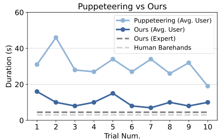

Fig. 7: User Study. Results on Battery Insertion for timing operators on both Ours and Puppeteering demonstrate a 50%+ gap in duration for both experienced and new operators.

Chú thích hình · tiếng Việt

Nghiên cứu người dùng. Thời gian lắp pin trên hệ thống đề xuất và tay dẫn cho thấy chênh lệch thời lượng trên 50% ở cả người có kinh nghiệm và người mới.

Hình 7 · Bằng chứng

### Bằng chứng khả năng vận hành

**Vai trò logic**

Nối thiết kế giao diện với tốc độ thao tác của người làm mẫu.

**Thủ pháp / điểm cần xét**

Đừng nhầm thời gian người điều khiển trong hình với thời gian chính sách tự hành ở Bảng III.

VI

## Conclusion Kết luận

Đóng góp hệ thống và giới hạn cảm nhận

§47PDF tr. 7EN → VI

In this paper, we present Flash ALOHA, a full-stack system for learning fast and precise manipulation. Our system presents a hardware setup for collecting high-speed demonstration, and a learning pipeline for smooth autonomous execution of fast and precise movements. Currently, the masking strategy that we use in the paper over-conservatively masks regions near human hands and arms, erasing potentially useful visual cues near human hands in the image space. Additionally, the whole system incorporates vision and proprioception as only two modalities, preventing the system from learning dexterous manipulation requiring contact-rich perception and control. In the future we would like to research adaptive masking strategies and including tactile sensing for better performance.

Bản dịch tiếng Việt

Bài báo giới thiệu Flash ALOHA, một hệ thống hoàn chỉnh để học thao tác vừa nhanh vừa chính xác, gồm phần cứng thu dữ liệu mẫu tốc độ cao và quy trình học giúp thực thi tự hành các chuyển động nhanh, chính xác một cách êm. Hiện tại, chiến lược mặt nạ che khá dư vùng gần bàn tay và cánh tay người, làm mất cả những dấu hiệu thị giác có thể hữu ích quanh tay. Ngoài ra, hệ thống chỉ có hai phương thức cảm nhận là thị giác và tự cảm nhận trạng thái, nên chưa thể học những thao tác khéo léo đòi hỏi cảm nhận và điều khiển giàu tiếp xúc. Trong tương lai, chúng tôi muốn nghiên cứu mặt nạ thích nghi và tích hợp cảm biến xúc giác để cải thiện hiệu năng.

§47 · Nhượng bộ / phản biện

### Kết luận, tự giới hạn và mở hướng tiếp theo

**Vai trò logic**

Khép lại luận đề bằng phạm vi đã đạt và những điều hệ thống còn thiếu.

**Thủ pháp / điểm cần xét**

Đây là nhượng bộ thực chất: lợi ích của mặt nạ đi kèm mất thông tin, còn xúc giác thuộc về người làm mẫu chứ chưa thuộc chính sách. Không nên gọi hệ thống là giải pháp tổng quát cho thao tác khéo léo.

—

## Acknowledgments Lời cảm ơn

Đóng góp, tài trợ và hỗ trợ phần cứng

§48PDF tr. 7–8EN → VI

We’d like to thank Ajay Sridhar, Yanjiang Guo, Brian Kim, Lars Ankile, Marcel Torne, Aneesh Muppidi, Ke Wang, Yuejiang Liu, Emily Jin, and Moo Jin Kim for helpful insights, discussions, and help filming. This work was supported by the Robotics and AI Institute. Zipeng Fu was supported by Pierre and Christine Lamond Fellowship. We appreciate the help from HESSIAN and ARX.

Bản dịch tiếng Việt

Chúng tôi cảm ơn Ajay Sridhar, Yanjiang Guo, Brian Kim, Lars Ankile, Marcel Torne, Aneesh Muppidi, Ke Wang, Yuejiang Liu, Emily Jin và Moo Jin Kim vì những trao đổi, nhận xét hữu ích và hỗ trợ quay phim. Công trình được Robotics and AI Institute tài trợ. Zipeng Fu nhận hỗ trợ từ học bổng Pierre and Christine Lamond. Chúng tôi trân trọng sự giúp đỡ từ HESSIAN và ARX.

§48 · Khái niệm

### Ghi nhận đóng góp và nguồn hỗ trợ

**Vai trò logic**

Cung cấp bối cảnh sản xuất tri thức; không phải một mắt xích chứng minh hiệu năng.

**Thủ pháp / điểm cần xét**

Hỗ trợ từ nhà cung cấp phần cứng là thông tin minh bạch cần giữ lại, nhưng tự nó không chứng minh hay bác bỏ chất lượng kết quả.

A.I

## Tracking Error During Policy Rollouts Phụ lục I · Sai số bám

Phân biệt sai số đo và sai số thực thi

§49PDF tr. 10EN → VI

Fig. 9 extends Fig. 2a with the commanded vs. achieved end-effector error of our arms during policy rollouts of each task. Fig. 10 shows the visual-inertial tracking setup.

Bản dịch tiếng Việt

Hình 9 mở rộng Hình 2a bằng sai số giữa vị trí đầu công tác được ra lệnh và vị trí thực đạt trên các tay máy khi chạy chính sách cho từng nhiệm vụ. Hình 10 trình bày cấu hình thí nghiệm theo dõi thị giác–quán tính.

§49 · Bằng chứng

### Bổ sung bằng chứng về bám quỹ đạo

**Vai trò logic**

Kiểm tra nút thắt ghi nhận tư thế bằng cách đặt sai số tracker cạnh sai số thực thi robot.

**Thủ pháp / điểm cần xét**

Hai đường sai số mô tả hai quá trình khác nhau: sai số đo tư thế và sai số bám lệnh. Đường cong là phép so sánh có ích, không có nghĩa encoder đo độc lập mọi sai số cơ khí của robot.

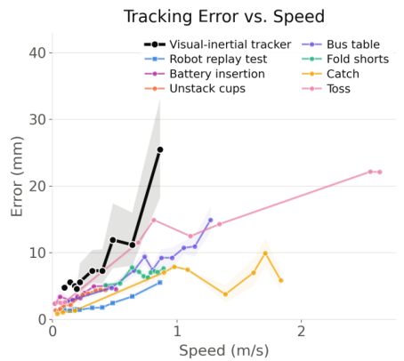

Chú thích hình · tiếng Việt

Hình 9 · Bằng chứng

### So sánh hai nguồn sai số

**Vai trò logic**

Mở rộng Hình 2 sang thực thi các nhiệm vụ, làm rõ lợi ích ghi trực tiếp từ encoder.

**Thủ pháp / điểm cần xét**

Miền tốc độ của tracker ngắn hơn một số đường robot; không ngoại suy đường tracker ra ngoài khoảng được thử.

A.II

## Visual-Inertial Tracking Experiment Phụ lục II · Thí nghiệm tracker

Thiết bị, căn chỉnh, thống kê và dữ liệu bị loại

§50PDF tr. 10EN → VI

Hardware. We mount an iPhone 15 Pro running the iPhUMI app on the wrist of a 6-DoF Seeed Studio reBot B601-RS arm with RobStride actuators, replacing the arm’s last link with the iPhUMI phone holder and hollow gripper fingers (Fig. 10). iPhUMI records the phone camera’s ARKit visual-inertial pose at about 60 Hz. It cannot stream poses live, so each recording is exported from the phone and aligned with the robot data offline. The phone stays seated in the holder throughout, and the transform X from the end effector to the phone camera is taken from the holder’s CAD model.

Bản dịch tiếng Việt

Phần cứng. Chúng tôi gắn iPhone 15 Pro chạy iPhUMI lên cổ tay của robot sáu bậc tự do Seeed Studio reBot B601-RS dùng bộ truyền động RobStride; khâu cuối được thay bằng giá điện thoại iPhUMI và ngón kẹp rỗng (Hình 10). iPhUMI ghi tư thế thị giác–quán tính ARKit của camera điện thoại ở khoảng 60 Hz. Ứng dụng không truyền tư thế trực tiếp, nên từng bản ghi được xuất từ điện thoại rồi căn chỉnh ngoại tuyến với dữ liệu robot. Điện thoại luôn nằm cố định trong giá; biến đổi X từ đầu công tác tới camera được lấy từ mô hình CAD của giá đỡ.

§50 · Phương pháp

### Mô tả phép thử tracker cụ thể

**Vai trò logic**

Làm rõ thiết bị thật đứng sau phê bình theo dõi thị giác–quán tính trong phần mở đầu.

**Thủ pháp / điểm cần xét**

Phạm vi chứng cứ là iPhone 15 Pro + iPhUMI/ARKit trong cấu hình này; chưa phải khảo sát nhiều tracker, thuật toán SLAM hay thiết bị thương mại.

§51PDF tr. 10EN → VI

Ground truth. The arm records its joint encoders, and forward kinematics gives the end-effector pose Ai at each sample. ARKit’s world frame is gravity-aligned, but its origin and heading are set wherever tracking starts, so it differs between recordings. For each take we fit one rigid transform Y from the ARKit world frame to the robot base by least squares over the whole take, and compare Ai with the tracker’s estimate of the end-effector pose Â<sub>i</sub> = Y B<sub>i</sub> X<sup>−1</sup>, where B<sub>i</sub> is the ARKit camera pose.

Bản dịch tiếng Việt

Chuẩn tham chiếu. Tay máy ghi số đo encoder khớp, rồi động học thuận cho tư thế đầu công tác A<sub>i</sub> ở mỗi mẫu. Hệ tọa độ thế giới của ARKit thẳng theo trọng lực, nhưng gốc và hướng được đặt tại vị trí bắt đầu theo dõi nên khác nhau giữa các bản ghi. Với mỗi bản ghi, chúng tôi khớp một phép biến đổi cứng Y từ hệ thế giới ARKit sang hệ gốc robot bằng bình phương tối thiểu trên toàn bộ bản ghi. Sau đó so sánh A<sub>i</sub> với tư thế đầu công tác do tracker ước lượng: Â<sub>i</sub> = Y B<sub>i</sub> X<sup>−1</sup>, trong đó B<sub>i</sub> là tư thế camera ARKit.

§51 · Phương pháp

### Xác định chuẩn đo và căn chỉnh không gian

**Vai trò logic**

Bảo đảm khác hệ tọa độ không bị nhầm thành lỗi theo dõi.

**Thủ pháp / điểm cần xét**

Khớp Y trên toàn bản ghi thuận lợi cho tracker vì đã loại bỏ lệch hệ cứng toàn cục. Encoder + FK vẫn phụ thuộc hiệu chuẩn và độ chính xác mô hình động học, không phải hệ đo ngoài độc lập.

§52PDF tr. 10EN → VI

Time alignment. The host and the phone are NTP-synchronized, and robot timestamps are mapped to Unix time through clock anchors recorded during each session. The remaining offset between the two streams, including pose latency, is found per take by cross-correlating the end effector’s angular speed from both sources, which does not depend on X or Y ; the peak correlation is at least 0.97 for every take. Tracker poses are then interpolated to the robot samples (linearly in position, spherically in rotation), and robot samples that fall in a gap of the tracker log are excluded rather than bridged.

Bản dịch tiếng Việt

Căn chỉnh thời gian. Máy chủ và điện thoại được đồng bộ NTP; mốc đồng hồ ghi trong từng phiên dùng để ánh xạ thời gian robot sang Unix. Độ lệch còn lại giữa hai luồng, kể cả độ trễ tư thế, được tìm riêng cho từng bản ghi bằng tương quan chéo vận tốc góc của đầu công tác từ hai nguồn; đại lượng này không phụ thuộc X hoặc Y. Tương quan cực đại đạt ít nhất 0,97 ở mọi bản ghi. Sau đó tư thế tracker được nội suy tới thời điểm lấy mẫu robot—tuyến tính với vị trí, nội suy cầu với quay. Các mẫu robot rơi vào khoảng trống của nhật ký tracker bị loại, không được nội suy bắc cầu.

§52 · Phương pháp

### Kiểm soát sai lệch đồng bộ

**Vai trò logic**

Loại một lời giải thích thay thế cho sai số tư thế: hai hệ đo lệch thời gian.

**Thủ pháp / điểm cần xét**

Tương quan cao hỗ trợ chất lượng căn chỉnh, không tự chứng minh tư thế chính xác. Loại vùng mất mẫu khiến các đường cong phản ánh phần có dữ liệu, không phản ánh trực tiếp tỷ lệ mất theo dõi.

§53PDF tr. 10EN → VI

Trajectories. An operator hand-guides the arm through four trajectories at 100 Hz while the phone records: a general motion, a free-space motion, a high-frequency motion and a motion with contact. The arm then replays each trajectory from its recorded joint positions at 0.25×, 0.5×, 0.75× and 1× speed, again with the phone recording. Including the hand-guided recordings, this gives 48 takes and 1,269 one-second windows, with end-effector speeds up to 1.2 m/s.

Bản dịch tiếng Việt

Quỹ đạo. Người vận hành dẫn tay máy qua bốn loại quỹ đạo ở 100 Hz trong khi điện thoại ghi: chuyển động tổng quát, chuyển động tự do trong không gian, chuyển động tần số cao và chuyển động có tiếp xúc. Sau đó, tay máy phát lại từng quỹ đạo từ vị trí khớp đã ghi ở các mức tốc độ 0,25×, 0,5×, 0,75× và 1×, đồng thời điện thoại tiếp tục ghi. Tính cả các lượt dẫn trực tiếp, tập thí nghiệm gồm 48 bản ghi và 1.269 cửa sổ dài một giây, với tốc độ đầu công tác lên tới 1,2 m/s.

§53 · Phương pháp

### Mô tả độ bao phủ phép đo

**Vai trò logic**

Đưa kiểm tra tracker ra khỏi một ví dụ đơn lẻ bằng nhiều kiểu chuyển động và mức tốc độ.

**Thủ pháp / điểm cần xét**

Không nên suy ra độ độc lập thống kê từ 1.269 cửa sổ vì chúng nằm trong 48 bản ghi. Bài không phân rã rõ số lượt lặp cho từng tổ hợp để tự tính lại con số 48.

§54PDF tr. 10EN → VI

Error metric. Each take is split into 1 s windows, and each window reports its top end-effector speed and the average end-effector position error. Windows with missing tracker samples are excluded. The curves in Fig. 2a and Fig. 9 are the mean over ten equal-count speed bins, with 95% bootstrap confidence intervals. For the robot’s own tracking error during the replays, we compare the commanded and achieved end-effector positions after removing one constant time lag per take, chosen to minimize the RMS error.

Bản dịch tiếng Việt

Thước đo sai số. Mỗi bản ghi được chia thành cửa sổ một giây; mỗi cửa sổ báo cáo tốc độ đầu công tác lớn nhất và sai số vị trí trung bình. Những cửa sổ thiếu mẫu tracker bị loại. Đường cong Hình 2a và Hình 9 là trung bình trong mười nhóm tốc độ có số mẫu bằng nhau, kèm khoảng tin cậy bootstrap 95%. Với sai số bám của chính robot khi phát lại, chúng tôi so sánh vị trí đầu công tác được lệnh và vị trí đạt được sau khi loại một độ trễ thời gian cố định riêng cho từng bản ghi, chọn để cực tiểu hóa sai số RMS.

§54 · Phương pháp

### Định nghĩa thống kê và xử lý độ trễ

**Vai trò logic**

Cho biết chính xác đường cong sai số đang đo cái gì và đã loại bỏ yếu tố nào.

**Thủ pháp / điểm cần xét**

Sai số bám đã được bù độ trễ không phải sai số thời gian thực thô. Bootstrap được báo cáo cho đường cong tracker, không cho các tỷ lệ thành công ở Bảng I–III; cách lấy mẫu bootstrap theo cửa sổ hay bản ghi chưa rõ.

§55PDF tr. 10EN → VI

Recording Failures. On the 1× speed takes for each trajectory, SLAM failures are rejected where the end effector is detected moving at more than 7.0 m/s by the iPhUMI kit. Due to this, each take at 1× speed on average took 3-4 tries to record without failure, making it impractical to test iPhUMI tracking on even faster trajectories.

Bản dịch tiếng Việt

Lỗi ghi nhận. Với các lượt chạy 1× của từng quỹ đạo, chúng tôi loại những bản ghi SLAM thất bại khi bộ iPhUMI phát hiện tốc độ đầu công tác vượt 7,0 m/s. Vì vậy, trung bình mỗi bản ghi ở 1× cần thử ba đến bốn lần mới có một lượt không lỗi. Điều này khiến việc thử iPhUMI ở các quỹ đạo còn nhanh hơn trở nên không thực tiễn.

§55 · Nhượng bộ / phản biện

### Công khai dữ liệu bị loại và thất bại đo

**Vai trò logic**

Bổ sung bằng chứng về độ tin cậy vận hành, đồng thời làm rõ điều kiện chọn mẫu của đường cong.

**Thủ pháp / điểm cần xét**

Các lần lỗi bị loại có thể khiến đường cong đánh giá thấp khó khăn thực tế. Ngưỡng 7,0 m/s là tiêu chí nhận diện lỗi, không phải tốc độ chuyển động hợp lệ tối đa của thí nghiệm (1,2 m/s).

[figure not shown]

Fig. 10: Visual-Inertial Setup. We add features beneficial to visual-inertial tracking, including a patterned tablecloth, bright lighting, 3-dimensional objects, and background clutter for maximum tracking performance.

Chú thích hình · tiếng Việt

Cấu hình thị giác–quán tính. Thí nghiệm bổ sung khăn bàn có họa tiết, ánh sáng mạnh, vật thể ba chiều và hậu cảnh nhiều chi tiết để hỗ trợ chất lượng theo dõi tối đa.

Hình 10 · Bằng chứng

### Kiểm soát bối cảnh đo

**Vai trò logic**

Cho thấy tracker được thử trong cảnh có các đặc trưng thị giác có lợi.

**Thủ pháp / điểm cần xét**

Các điều kiện này củng cố phép thử cụ thể, nhưng chưa chứng minh hiệu quả trong mọi môi trường hoặc với mọi thuật toán theo dõi.

A.III

## Puppeteering Baseline Setup Phụ lục III · Baseline tay dẫn

Cấu hình ALOHA 2 và các can thiệp tăng tốc

§56PDF tr. 10EN → VI

Data collection. For the puppeteering comparisons in Table III, an operator collects demonstrations by teleoperating an ALOHA 2 with its leader arms. Each task has 50 demonstrations recorded at 50 Hz, with joint positions of both arms and grippers (14 dimensions) and images from a top camera and two wrist cameras at 640 × 480. Table IV lists the datasets.

Bản dịch tiếng Việt

Thu dữ liệu. Trong các so sánh tay dẫn ở Bảng III, người vận hành dùng tay dẫn của ALOHA 2 để điều khiển và làm mẫu. Mỗi nhiệm vụ có 50 lượt mẫu ghi ở 50 Hz, gồm vị trí khớp của hai tay và bộ kẹp (14 chiều), cùng ảnh từ một camera trên cao và hai camera cổ tay ở độ phân giải 640 × 480. Bảng IV liệt kê các tập dữ liệu.

§56 · Phương pháp

### Làm rõ baseline và lượng dữ liệu

**Vai trò logic**

Giúp đánh giá tính công bằng về số lượt mẫu, cấu hình cảm biến và nền tảng robot.

**Thủ pháp / điểm cần xét**

Số lượt mẫu bằng nhau không có nghĩa tổng thời lượng, độ phân giải nguồn hoặc khả năng cơ khí bằng nhau. Bảng IV cho thời lượng baseline 12/20/18 giây, dài hơn dữ liệu trực tiếp.

§57PDF tr. 10EN → VI

Policy. We train one ACT policy per task with the same architecture as ours (Table VI): ResNet-18 image backbone, no CVAE encoder, hidden dimension 512, feedforward dimension 3200, 4 encoder and 7 decoder layers with 8 heads, and a chunk size of 50 actions (1 s at 50 Hz). Policies take the three images at 320 × 180 and the joint positions, and are trained with batch size 256, learning rate 2×10−4, backbone learning rate 10−5 and data augmentation.

Bản dịch tiếng Việt

Chính sách. Mỗi nhiệm vụ được huấn luyện một chính sách ACT với cùng kiến trúc như hệ thống đề xuất (Bảng VI): backbone ảnh ResNet-18, không có bộ mã hóa CVAE, chiều ẩn 512, chiều mạng truyền thẳng 3.200, bốn lớp mã hóa, bảy lớp giải mã, tám đầu chú ý và đoạn 50 hành động (một giây ở 50 Hz). Chính sách nhận ba ảnh 320 × 180 và vị trí khớp, được huấn luyện với batch size 256, tốc độ học 2 × 10⁻⁴, tốc độ học backbone 10⁻⁵ và tăng cường dữ liệu.

§57 · Phương pháp

### Kiểm soát kiến trúc học ở baseline

**Vai trò logic**

Loại bớt khả năng baseline kém chỉ vì dùng một kiến trúc chính sách yếu hơn.

**Thủ pháp / điểm cần xét**

Đồng nhất kiến trúc tăng sức nặng so sánh, nhưng không loại bỏ khác biệt phần cứng, dữ liệu và thông số triển khai. ‘320 × 180’ và ‘180 × 320’ có thể là quy ước rộng–cao khác nhau, cần kiểm tra mã nếu tái lập.

§58PDF tr. 10EN → VI

Deployment. Puppeteering executes each chunk at the 50 Hz collection rate and queries a new chunk every 1 s. Puppet Double Freq executes the same chunks at 100 Hz and queries every 0.5 s. Puppet Skip Actions keeps the 50 Hz controller but executes every other action of each chunk, also querying every 0.5 s. Both sped-up variants therefore traverse each chunk in half the time of the collected data.

Bản dịch tiếng Việt

Triển khai. Puppeteering thực hiện mỗi đoạn ở tần số thu mẫu 50 Hz và yêu cầu đoạn mới mỗi một giây. Puppet Double Freq thực hiện cùng các đoạn ở 100 Hz, yêu cầu đoạn mới mỗi 0,5 giây. Puppet Skip Actions giữ bộ điều khiển 50 Hz nhưng chỉ thực thi mỗi hành động xen kẽ trong đoạn, cũng yêu cầu đoạn mới mỗi 0,5 giây. Vì vậy, cả hai biến thể tăng tốc đều đi qua một đoạn trong một nửa thời gian của dữ liệu gốc.

§58 · Phương pháp

### Cụ thể hóa hai can thiệp tăng tốc

**Vai trò logic**

Cho thấy hai baseline cùng nén thời gian gấp đôi nhưng thay đổi chuỗi lệnh theo hai cách khác nhau.

**Thủ pháp / điểm cần xét**

Không được gọi thời gian hoàn thành toàn nhiệm vụ giảm đúng một nửa: thất bại, phản hồi và quỹ đạo thực thi khiến các con số Bảng III khác tỷ lệ lý tưởng của từng đoạn.

Bảng IV · Toàn bộ số liệu

**TABLE IV:** Puppeteering Data. ALOHA 2 teleoperation datasets used for the puppeteering baselines, recorded at 50 Hz; Length is the recorded episode length.

Chú thích bảng · tiếng Việt

Dữ liệu tay dẫn. Các tập dữ liệu điều khiển từ xa ALOHA 2 cho baseline, ghi ở 50 Hz; Length là độ dài episode đã ghi.

Bảng I–III: các cột thành công tính theo %; Time tính theo giây. Có thể cuộn ngang từng bảng trên màn hình nhỏ. C&S, B&P giữ ký hiệu gốc.

ALOHA 2

| Method / Hạng mục | Demos · Số mẫu | Length · Giây | Training steps · Bước |
| --- | --- | --- | --- |
| Unstack Cups | 50 | 12 s | 200k |
| Battery Insertion | 50 | 20 s | 200k |
| Bus Table | 50 | 18 s | 200k |

Bảng IV · Phương pháp

### Đọc Bảng IV

**Vai trò logic**

Giữ cả kết quả trung gian, thành công toàn nhiệm vụ và thời gian để tránh chọn số có lợi.

**Thủ pháp / điểm cần xét**

Cả hai hệ thống có 50 lượt mẫu mỗi tác vụ so sánh, nhưng tổng thời lượng dữ liệu khác nhau. Không đồng nhất độ dài episode được ghi với thời gian hoàn thành trong Bảng III.

A.IV

## Chunk Boundary Jumps Phụ lục IV · Bước nhảy lệnh

Chỉ dấu định lượng của sự gián đoạn

§59PDF tr. 10–11EN → VI

Fig. 8 measures the discontinuities between action chunks in the speed comparisons of Table III. At each policy update, we take the change in commanded joint positions between the last action of the previous chunk and the first action of the new one, as the Euclidean norm over the 12 arm joints (grippers excluded). Each rollout contributes the average jump over its chunk boundaries, and every rollout is included, failures as well. Doubling the controller frequency makes the jumps about 3–3.5× those of puppeteering, while skipping every other action makes them 1.5–2×.

Bản dịch tiếng Việt

Hình 8 đo sự gián đoạn giữa các đoạn hành động trong so sánh tốc độ của Bảng III. Ở mỗi lần cập nhật chính sách, chúng tôi tính thay đổi vị trí khớp được lệnh giữa hành động cuối đoạn trước và hành động đầu đoạn mới bằng chuẩn Euclid trên 12 khớp tay máy, không tính bộ kẹp. Mỗi lượt chạy đóng góp bước nhảy trung bình qua các ranh giới đoạn của nó; tất cả lượt chạy đều được tính, kể cả thất bại. Tăng gấp đôi tần số làm bước nhảy lớn khoảng 3–3,5 lần so với puppeteering, còn bỏ hành động xen kẽ làm tăng khoảng 1,5–2 lần.

§59 · Bằng chứng

### Định lượng cơ chế gây giật

**Vai trò logic**

Bổ trợ cách giải thích kết quả tăng tốc bằng một đại lượng lệnh điều khiển đo được.

**Thủ pháp / điểm cần xét**

Hình 8 gồm 20 lượt mỗi điều kiện, riêng Puppeteering/dọn bàn là 19. Chuẩn của vector vị trí không trực tiếp đo lực giật, gia tốc hay ổn định; biểu đồ này cũng không có cột Ours để so trực tiếp.

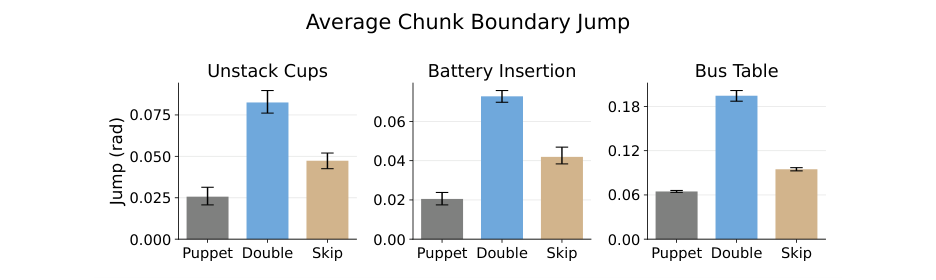

Fig. 8: Average Chunk Boundary Jump. Average change in commanded joint positions at chunk boundaries for Puppeteering (Puppet), Puppet Double Freq (Double) and Puppet Skip Actions (Skip). Bars: mean over 20 rollouts per condition (19 for Puppeteering on Bus Table)

Chú thích hình · tiếng Việt

Bước nhảy trung bình tại ranh giới đoạn. Thay đổi vị trí khớp lệnh cho Puppeteering (Puppet), Puppet Double Freq (Double) và Puppet Skip Actions (Skip). Cột biểu diễn trung bình trên 20 lượt mỗi điều kiện, riêng Puppeteering/dọn bàn có 19 lượt.

Hình 8 · Bằng chứng

### Bằng chứng gián đoạn lệnh

**Vai trò logic**

Hỗ trợ quan sát tăng tốc làm bước nhảy tăng mạnh.

**Thủ pháp / điểm cần xét**

Chú thích không định nghĩa thanh sai số; không nên tự gọi chúng là khoảng tin cậy. Không có cột Flash ALOHA trong hình này.

A.V

## Policy Training Details Phụ lục V · Huấn luyện

Dữ liệu, kiến trúc ACT và điều kiện tái lập

§60PDF tr. 11EN → VI

We train ACT [1] policies on the demonstrations. Table V lists the datasets and Table VI the ACT configuration. Images are recorded at 360 × 640 and downsampled to 180 × 320 for the policy, and training augments them with random crops covering 95% of each side, resized back to the input resolution. Policies predict absolute joint positions and gripper commands, are conditioned on joint positions only (no velocities), and are trained with seed 0 on a single GPU (NVIDIA L40S, A40 or RTX 4090), holding out 1% of the episodes for validation.

Bản dịch tiếng Việt

Chúng tôi huấn luyện chính sách ACT [1] trên các lượt làm mẫu. Bảng V liệt kê dữ liệu và Bảng VI trình bày cấu hình ACT. Ảnh được ghi ở 360 × 640 rồi giảm xuống 180 × 320 cho chính sách. Tăng cường dữ liệu dùng cắt ngẫu nhiên giữ 95% mỗi chiều rồi đổi về kích thước đầu vào. Chính sách dự đoán vị trí khớp tuyệt đối và lệnh bộ kẹp, chỉ điều kiện hóa theo vị trí khớp, không dùng vận tốc. Huấn luyện dùng seed 0 trên một GPU NVIDIA L40S, A40 hoặc RTX 4090; 1% số episode được giữ lại để kiểm định.

§60 · Phương pháp

### Cung cấp điều kiện tái lập và giới hạn thống kê

**Vai trò logic**

Làm rõ lượng thông tin thực sự đi vào chính sách và cách huấn luyện các kết quả chính.

**Thủ pháp / điểm cần xét**

Chỉ một seed được nêu, chưa có biến thiên qua nhiều lần huấn luyện. Với 50 episode, 1% tương đương 0,5 episode nên quy tắc làm tròn tập kiểm định chưa rõ; đây là thông tin cần bổ sung khi tái lập.

Bảng V · Toàn bộ số liệu

**TABLE V:** Training Data. Demonstrations per task, recorded by kinesthetic teaching. L and R are the wrist cameras; Length is the task duration. Toss & Catch records the tossing arm at 100 Hz and the catching arm at 200 Hz.

Chú thích bảng · tiếng Việt

Dữ liệu huấn luyện. Các lượt mẫu theo nhiệm vụ được ghi bằng dẫn động trực tiếp. L và R là camera cổ tay; Length là thời lượng nhiệm vụ. Với tung–bắt bóng, tay tung ghi ở 100 Hz còn tay bắt ở 200 Hz.

Bảng I–III: các cột thành công tính theo %; Time tính theo giây. Có thể cuộn ngang từng bảng trên màn hình nhỏ. C&S, B&P giữ ký hiệu gốc.

Kinesthetic teaching

| Method / Hạng mục | Arms · Tay máy | Cameras · Camera | Rate · Tần số | Demos · Số mẫu | Length · Giây |
| --- | --- | --- | --- | --- | --- |
| Unstack Cups | ARX, 2 | L, R, Top | 50 Hz | 50 | 4 s |
| Battery Insertion | ARX, 2 | L, R, Top | 50 Hz | 50 | 7 s |
| Bus Table | ARX, 2 | L, R, Top | 50 Hz | 50 | 6 s |
| Fold Shorts | ARX, 2 | L, R, Top | 50 Hz | 50 | 5 s |
| Toss & Catch | HESSIAN, 2 | L, R, Top | 100/200 Hz | 50 | 2 s |

Bảng V · Phương pháp

### Đọc Bảng V

**Vai trò logic**

Giữ cả kết quả trung gian, thành công toàn nhiệm vụ và thời gian để tránh chọn số có lợi.

**Thủ pháp / điểm cần xét**

Tung–bắt bóng là ngoại lệ của mô tả chung 50 Hz: bảng ghi hai tần số tay máy 100/200 Hz. Thời lượng mẫu không phải thời gian thực thi chính sách.

Bảng VI · Toàn bộ số liệu

**TABLE VI:** ACT Configuration.

Chú thích bảng · tiếng Việt

Cấu hình ACT.

Bảng I–III: các cột thành công tính theo %; Time tính theo giây. Có thể cuộn ngang từng bảng trên màn hình nhỏ. C&S, B&P giữ ký hiệu gốc.

ACT

| Method / Hạng mục | Value · Giá trị |
| --- | --- |
| Policy · Chính sách | ACT, no CVAE encoder |
| Image backbone | ResNet-18 |
| Hidden / feedforward dim. | 512 / 3200 |
| Encoder / decoder layers | 4 / 7 |
| Attention heads | 8 |
| Chunk size | 50 |
| Batch size | 256 |
| Learning rate | 2 × 10⁻⁴ |
| Optimizer | AdamW, weight decay 10⁻⁴ |
| Training steps | 200k |

Bảng VI · Phương pháp

### Đọc Bảng VI

**Vai trò logic**

Giữ cả kết quả trung gian, thành công toàn nhiệm vụ và thời gian để tránh chọn số có lợi.

**Thủ pháp / điểm cần xét**

Bảng này chưa nêu cửa sổ làm trơn H, thang sigmoid σ và số hành động nhìn trước n. Không nên coi cấu hình kiến trúc là đủ để tái lập toàn bộ hệ thống.

REF

## References Tài liệu tham khảo

Giữ đủ 59 mục theo PDF; dịch tên công trình để hỗ trợ đọc, không thay đổi thông tin xuất bản.

Các chú giải dưới đây chỉ xác định vai trò trích dẫn trong Flash ALOHA, không phải thẩm định độc lập 59 công trình. Tên riêng, tên hội nghị, số arXiv và năm được giữ theo bản gốc; danh mục nguồn chưa được đối chiếu ngoài PDF.

[1] T. Z. Zhao, V. Kumar, S. Levine, and C. Finn, “Learning fine-grained bimanual manipulation with low-cost hardware,” RSS, 2023.

Tên công trình · tiếng Việt

Học thao tác hai tay tinh vi bằng phần cứng chi phí thấp

[1] · Khái niệm

### Dẫn nguồn [1]

**Vai trò logic**

Nền tảng trực tiếp cho ACT, phân đoạn hành động và bài toán thực thi thời gian thực.

**Thủ pháp / điểm cần xét**

Trích dẫn tạo bối cảnh hoặc nền tảng kỹ thuật; không thay cho kiểm chứng thực nghiệm của hệ thống đề xuất.

[2] Z. Fu, T. Z. Zhao, and C. Finn, “Mobile aloha: Learning bimanual mobile manipulation with low-cost whole-body teleoperation,” in CoRL, 2024.

Tên công trình · tiếng Việt

Mobile ALOHA: học thao tác di động hai tay bằng điều khiển từ xa toàn thân chi phí thấp

[2] · Khái niệm

### Dẫn nguồn [2]

**Vai trò logic**

Bối cảnh các giao diện thu dữ liệu, điều khiển từ xa và khoảng cách người–robot (Mục II).

**Thủ pháp / điểm cần xét**

Trích dẫn tạo bối cảnh hoặc nền tảng kỹ thuật; không thay cho kiểm chứng thực nghiệm của hệ thống đề xuất.

[3] K. Black, M. Y. Galliker, and S. Levine, “Real-time execution of action chunking flow policies,” arXiv preprint arXiv:2506.07339, 2025.

Tên công trình · tiếng Việt

Thực thi thời gian thực các chính sách luồng phân đoạn hành động

[3] · Khái niệm

### Dẫn nguồn [3]

**Vai trò logic**

Nền tảng trực tiếp cho ACT, phân đoạn hành động và bài toán thực thi thời gian thực.

**Thủ pháp / điểm cần xét**

Trích dẫn tạo bối cảnh hoặc nền tảng kỹ thuật; không thay cho kiểm chứng thực nghiệm của hệ thống đề xuất.

[4] Y. Zhu, J. Wong, A. Mandlekar, and R. Mart´ın-Mart´ın, “robosuite: A modular simulation framework and benchmark for robot learning,” arXiv preprint arXiv:2009.12293, 2020.

Tên công trình · tiếng Việt

robosuite: khung mô phỏng mô-đun và bộ chuẩn đánh giá cho học robot

[4] · Khái niệm

### Dẫn nguồn [4]

**Vai trò logic**

Bối cảnh các giao diện thu dữ liệu, điều khiển từ xa và khoảng cách người–robot (Mục II).

**Thủ pháp / điểm cần xét**

Trích dẫn tạo bối cảnh hoặc nền tảng kỹ thuật; không thay cho kiểm chứng thực nghiệm của hệ thống đề xuất.

[5] T. Zhang, Z. McCarthy, O. Jow, D. Lee, X. Chen, K. Goldberg, and P. Abbeel, “Deep imitation learning for complex manipulation tasks from virtual reality teleoperation,” in 2018 ICRA, 2018.

Tên công trình · tiếng Việt

Học bắt chước sâu cho thao tác phức tạp từ điều khiển từ xa thực tế ảo

[5] · Khái niệm

### Dẫn nguồn [5]

**Vai trò logic**

Bối cảnh các giao diện thu dữ liệu, điều khiển từ xa và khoảng cách người–robot (Mục II).

**Thủ pháp / điểm cần xét**

Trích dẫn tạo bối cảnh hoặc nền tảng kỹ thuật; không thay cho kiểm chứng thực nghiệm của hệ thống đề xuất.

[6] C. Chi, Z. Xu, C. Pan, E. Cousineau, B. Burchfiel, S. Feng, R. Tedrake, and S. Song, “Universal manipulation interface: In-the-wild robot teaching without in-the-wild robots,” in Proceedings of Robotics: Science and Systems (RSS), 2024.

Tên công trình · tiếng Việt

Giao diện thao tác phổ quát: dạy robot ngoài thực địa mà không cần robot ngoài thực địa

[6] · Khái niệm

### Dẫn nguồn [6]

**Vai trò logic**

Bối cảnh các giao diện thu dữ liệu, điều khiển từ xa và khoảng cách người–robot (Mục II).

**Thủ pháp / điểm cần xét**

Trích dẫn tạo bối cảnh hoặc nền tảng kỹ thuật; không thay cho kiểm chứng thực nghiệm của hệ thống đề xuất.

[7] A. Billard, S. Calinon, R. Dillmann, and S. Schaal, “Robot programming by demonstration,” in Springer handbook of robotics. Springer, 2008, pp. 1371–1394.

Tên công trình · tiếng Việt

Lập trình robot bằng làm mẫu

[7] · Khái niệm

### Dẫn nguồn [7]

**Vai trò logic**

Bối cảnh các giao diện thu dữ liệu, điều khiển từ xa và khoảng cách người–robot (Mục II).

**Thủ pháp / điểm cần xét**

Trích dẫn tạo bối cảnh hoặc nền tảng kỹ thuật; không thay cho kiểm chứng thực nghiệm của hệ thống đề xuất.

[8] S. Kareer, D. Patel, R. Punamiya, P. Mathur, S. Cheng, C. Wang, J. Hoffman, and D. Xu, “Egomimic: Scaling imitation learning via egocentric video,” in 2025 ICRA, 2025.

Tên công trình · tiếng Việt

EgoMimic: mở rộng học bắt chước qua video góc nhìn thứ nhất

[8] · Khái niệm

### Dẫn nguồn [8]

**Vai trò logic**

Bối cảnh các giao diện thu dữ liệu, điều khiển từ xa và khoảng cách người–robot (Mục II).

**Thủ pháp / điểm cần xét**

Trích dẫn tạo bối cảnh hoặc nền tảng kỹ thuật; không thay cho kiểm chứng thực nghiệm của hệ thống đề xuất.

[9] M. Lepert, J. Fang, and J. Bohg, “Phantom: Training robots without robots using only human videos,” arXiv preprint arXiv:2503.00779, 2025.

Tên công trình · tiếng Việt

Phantom: huấn luyện robot mà không cần robot, chỉ dùng video con người

[9] · Khái niệm

### Dẫn nguồn [9]

**Vai trò logic**

Bối cảnh các giao diện thu dữ liệu, điều khiển từ xa và khoảng cách người–robot (Mục II).

**Thủ pháp / điểm cần xét**

Trích dẫn tạo bối cảnh hoặc nền tảng kỹ thuật; không thay cho kiểm chứng thực nghiệm của hệ thống đề xuất.

[10] L. Y. Zhu, P. Kuppili, R. Punamiya, P. Aphiwetsa, D. Patel, S. Kareer, S. Ha, and D. Xu, “Emma: Scaling mobile manipulation via egocentric human data,” arXiv preprint arXiv:2509.04443, 2025.

Tên công trình · tiếng Việt

EMMA: mở rộng thao tác di động bằng dữ liệu con người góc nhìn thứ nhất

[10] · Khái niệm

### Dẫn nguồn [10]

**Vai trò logic**

Bối cảnh các giao diện thu dữ liệu, điều khiển từ xa và khoảng cách người–robot (Mục II).

**Thủ pháp / điểm cần xét**

Trích dẫn tạo bối cảnh hoặc nền tảng kỹ thuật; không thay cho kiểm chứng thực nghiệm của hệ thống đề xuất.

[11] H. Xiong, R. Mendonca, K. Shaw, and D. Pathak, “Adaptive mobile manipulation for articulated objects in the open world,” arXiv preprint arXiv:2401.14403, 2024.

Tên công trình · tiếng Việt

Thao tác di động thích nghi với vật thể có khớp trong thế giới mở

[11] · Khái niệm

### Dẫn nguồn [11]

**Vai trò logic**

Bối cảnh các giao diện thu dữ liệu, điều khiển từ xa và khoảng cách người–robot (Mục II).

**Thủ pháp / điểm cần xét**

Trích dẫn tạo bối cảnh hoặc nền tảng kỹ thuật; không thay cho kiểm chứng thực nghiệm của hệ thống đề xuất.

[12] Y. Zhu, A. Joshi, P. Stone, and Y. Zhu, “Viola: Imitation learning for vision-based manipulation with object proposal priors,” in CoRL. PMLR, 2023, pp. 1199–1210.

Tên công trình · tiếng Việt

VIOLA: học bắt chước cho thao tác dựa trên thị giác với tiên nghiệm đề xuất vật thể

[12] · Khái niệm

### Dẫn nguồn [12]

**Vai trò logic**

Bối cảnh các giao diện thu dữ liệu, điều khiển từ xa và khoảng cách người–robot (Mục II).

**Thủ pháp / điểm cần xét**

Trích dẫn tạo bối cảnh hoặc nền tảng kỹ thuật; không thay cho kiểm chứng thực nghiệm của hệ thống đề xuất.

[13] S. Ross, N. Melik-Barkhudarov, K. S. Shankar, A. Wendel, D. Dey, J. A. Bagnell, and M. Hebert, “Learning monocular reactive uav control in cluttered natural environments,” in 2013 ICRA, 2013.

Tên công trình · tiếng Việt

Học điều khiển phản ứng từ một camera cho UAV trong môi trường lộn xộn

[13] · Khái niệm

### Dẫn nguồn [13]

**Vai trò logic**

Bối cảnh các giao diện thu dữ liệu, điều khiển từ xa và khoảng cách người–robot (Mục II).

**Thủ pháp / điểm cần xét**

Trích dẫn tạo bối cảnh hoặc nền tảng kỹ thuật; không thay cho kiểm chứng thực nghiệm của hệ thống đề xuất.

[14] A. Mandlekar, Y. Zhu, A. Garg, J. Booher, M. Spero, A. Tung, J. Gao, J. Emmons, A. Gupta, E. Orbay et al., “Roboturk: A crowdsourcing platform for robotic skill learning through imitation,” in CoRL. PMLR, 2018, pp. 879–893.

Tên công trình · tiếng Việt

RoboTurk: nền tảng huy động cộng đồng cho học kỹ năng robot qua bắt chước

[14] · Khái niệm

### Dẫn nguồn [14]

**Vai trò logic**

Bối cảnh các giao diện thu dữ liệu, điều khiển từ xa và khoảng cách người–robot (Mục II).

**Thủ pháp / điểm cần xét**

Trích dẫn tạo bối cảnh hoặc nền tảng kỹ thuật; không thay cho kiểm chứng thực nghiệm của hệ thống đề xuất.

[15] X. Cheng, J. Li, S. Yang, G. Yang, and X. Wang, “Open-television: Teleoperation with immersive active visual feedback,” arXiv preprint arXiv:2407.01512, 2024.

Tên công trình · tiếng Việt

Open-TeleVision: điều khiển từ xa với phản hồi thị giác chủ động nhập vai

[15] · Khái niệm

### Dẫn nguồn [15]

**Vai trò logic**

Bối cảnh các giao diện thu dữ liệu, điều khiển từ xa và khoảng cách người–robot (Mục II).

**Thủ pháp / điểm cần xét**

Trích dẫn tạo bối cảnh hoặc nền tảng kỹ thuật; không thay cho kiểm chứng thực nghiệm của hệ thống đề xuất.

[16] Y. Park, J. S. Bhatia, L. Ankile, and P. Agrawal, “Dexhub and dart: Towards internet scale robot data collection,” arXiv preprint arXiv:2411.02214, 2024.

Tên công trình · tiếng Việt

DexHub và DART: hướng tới thu dữ liệu robot ở quy mô Internet

[16] · Khái niệm

### Dẫn nguồn [16]

**Vai trò logic**

Bối cảnh các giao diện thu dữ liệu, điều khiển từ xa và khoảng cách người–robot (Mục II).

**Thủ pháp / điểm cần xét**

Trích dẫn tạo bối cảnh hoặc nền tảng kỹ thuật; không thay cho kiểm chứng thực nghiệm của hệ thống đề xuất.

[17] M. Seo, S. Han, K. Sim, S. H. Bang, C. Gonzalez, L. Sentis, and Y. Zhu, “Deep imitation learning for humanoid loco-manipulation through human teleoperation,” in 2023 Humanoids, 2023.

Tên công trình · tiếng Việt

Học bắt chước sâu cho di chuyển–thao tác của robot hình người qua điều khiển từ xa

[17] · Khái niệm

### Dẫn nguồn [17]

**Vai trò logic**

Bối cảnh các giao diện thu dữ liệu, điều khiển từ xa và khoảng cách người–robot (Mục II).

**Thủ pháp / điểm cần xét**

Trích dẫn tạo bối cảnh hoặc nền tảng kỹ thuật; không thay cho kiểm chứng thực nghiệm của hệ thống đề xuất.

[18] A. Handa, K. Van Wyk, W. Yang, J. Liang, Y.-W. Chao, Q. Wan, S. Birchfield, N. Ratliff, and D. Fox, “Dexpilot: Vision-based teleoperation of dexterous robotic hand-arm system,” in 2020 ICRA, 2020.

Tên công trình · tiếng Việt

DexPilot: điều khiển từ xa hệ tay–cánh tay khéo léo dựa trên thị giác

[18] · Khái niệm

### Dẫn nguồn [18]

**Vai trò logic**

Bối cảnh các giao diện thu dữ liệu, điều khiển từ xa và khoảng cách người–robot (Mục II).

**Thủ pháp / điểm cần xét**

Trích dẫn tạo bối cảnh hoặc nền tảng kỹ thuật; không thay cho kiểm chứng thực nghiệm của hệ thống đề xuất.

[19] A. Sivakumar, K. Shaw, and D. Pathak, “Robotic telekinesis: Learning a robotic hand imitator by watching humans on youtube,” arXiv preprint arXiv:2202.10448, 2022.

Tên công trình · tiếng Việt

Điều khiển từ xa bằng thị giác: học tay robot bắt chước bằng cách xem người trên YouTube

[19] · Khái niệm

### Dẫn nguồn [19]

**Vai trò logic**

Bối cảnh các giao diện thu dữ liệu, điều khiển từ xa và khoảng cách người–robot (Mục II).

**Thủ pháp / điểm cần xét**

Trích dẫn tạo bối cảnh hoặc nền tảng kỹ thuật; không thay cho kiểm chứng thực nghiệm của hệ thống đề xuất.

[20] Z. Fu, Q. Zhao, Q. Wu, G. Wetzstein, and C. Finn, “Humanplus: Humanoid shadowing and imitation from humans,” in CoRL, 2024.

Tên công trình · tiếng Việt

HumanPlus: bám theo và bắt chước con người bằng robot hình người

[20] · Khái niệm

### Dẫn nguồn [20]

**Vai trò logic**

Bối cảnh các giao diện thu dữ liệu, điều khiển từ xa và khoảng cách người–robot (Mục II).

**Thủ pháp / điểm cần xét**

Trích dẫn tạo bối cảnh hoặc nền tảng kỹ thuật; không thay cho kiểm chứng thực nghiệm của hệ thống đề xuất.

[21] T. He, Z. Luo, W. Xiao, C. Zhang, K. Kitani, C. Liu, and G. Shi, “Learning human-to-humanoid real-time whole-body teleoperation,” arXiv preprint arXiv:2403.04436, 2024.

Tên công trình · tiếng Việt

Học điều khiển từ xa toàn thân thời gian thực từ người sang robot hình người

[21] · Khái niệm

### Dẫn nguồn [21]

**Vai trò logic**

Bối cảnh các giao diện thu dữ liệu, điều khiển từ xa và khoảng cách người–robot (Mục II).

**Thủ pháp / điểm cần xét**

Trích dẫn tạo bối cảnh hoặc nền tảng kỹ thuật; không thay cho kiểm chứng thực nghiệm của hệ thống đề xuất.

[22] H. Fang, H.-S. Fang, Y. Wang, J. Ren, J. Chen, R. Zhang, W. Wang, and C. Lu, “Airexo: Low-cost exoskeletons for learning whole-arm manipulation in the wild,” in 2024 ICRA, 2024.

Tên công trình · tiếng Việt

AirExo: bộ khung ngoài chi phí thấp để học thao tác toàn cánh tay ngoài thực địa

[22] · Khái niệm

### Dẫn nguồn [22]

**Vai trò logic**

Bối cảnh các giao diện thu dữ liệu, điều khiển từ xa và khoảng cách người–robot (Mục II).

**Thủ pháp / điểm cần xét**

Trích dẫn tạo bối cảnh hoặc nền tảng kỹ thuật; không thay cho kiểm chứng thực nghiệm của hệ thống đề xuất.

[23] A. Purushottam, C. Xu, Y. Jung, and J. Ramos, “Dynamic mobile manipulation via whole-body bilateral teleoperation of a wheeled humanoid,” IEEE Robotics and Automation Letters, 2023.

Tên công trình · tiếng Việt

Thao tác di động động bằng điều khiển từ xa hai chiều toàn thân robot hình người có bánh xe

[23] · Khái niệm

### Dẫn nguồn [23]

**Vai trò logic**

Bối cảnh các giao diện thu dữ liệu, điều khiển từ xa và khoảng cách người–robot (Mục II).

**Thủ pháp / điểm cần xét**

Trích dẫn tạo bối cảnh hoặc nền tảng kỹ thuật; không thay cho kiểm chứng thực nghiệm của hệ thống đề xuất.

[24] C. Wang, H. Shi, W. Wang, R. Zhang, L. Fei-Fei, and C. K. Liu, “Dexcap: Scalable and portable mocap data collection system for dexterous manipulation,” arXiv preprint arXiv:2403.07788, 2024.

Tên công trình · tiếng Việt

DexCap: hệ ghi chuyển động mở rộng và di động cho thu dữ liệu thao tác khéo léo

[24] · Khái niệm

### Dẫn nguồn [24]

**Vai trò logic**

Bối cảnh các giao diện thu dữ liệu, điều khiển từ xa và khoảng cách người–robot (Mục II).

**Thủ pháp / điểm cần xét**

Trích dẫn tạo bối cảnh hoặc nền tảng kỹ thuật; không thay cho kiểm chứng thực nghiệm của hệ thống đề xuất.

[25] H. Etukuru, N. Naka, Z. Hu, S. Lee, J. Mehu, A. Edsinger, C. Paxton, S. Chintala, L. Pinto, and N. M. M. Shafiullah, “Robot utility models: General policies for zero-shot deployment in new environments,” in 2025 ICRA, 2025.

Tên công trình · tiếng Việt

Mô hình tiện ích robot: chính sách tổng quát triển khai zero-shot trong môi trường mới

[25] · Khái niệm

### Dẫn nguồn [25]

**Vai trò logic**

Bối cảnh các giao diện thu dữ liệu, điều khiển từ xa và khoảng cách người–robot (Mục II).

**Thủ pháp / điểm cần xét**

Trích dẫn tạo bối cảnh hoặc nền tảng kỹ thuật; không thay cho kiểm chứng thực nghiệm của hệ thống đề xuất.

[26] R. Jenness and C. Wicker, “Master–slave manipulators and remote maintenance at the oak ridge national laboratory,” Oak Ridge National Lab., Tenn.(USA), Tech. Rep., 1975.

Tên công trình · tiếng Việt

Bộ thao tác chủ–tớ và bảo trì từ xa tại Phòng thí nghiệm Quốc gia Oak Ridge

[26] · Khái niệm

### Dẫn nguồn [26]

**Vai trò logic**

Bối cảnh các giao diện thu dữ liệu, điều khiển từ xa và khoảng cách người–robot (Mục II).

**Thủ pháp / điểm cần xét**

Trích dẫn tạo bối cảnh hoặc nền tảng kỹ thuật; không thay cho kiểm chứng thực nghiệm của hệ thống đề xuất.

[27] P. Wu, Y. Shentu, Z. Yi, X. Lin, and P. Abbeel, “Gello: A general, low-cost, and intuitive teleoperation framework for robot manipulators,” in 2024 IROS, 2024.

Tên công trình · tiếng Việt

GELLO: khung điều khiển từ xa tổng quát, chi phí thấp và trực quan cho tay máy

[27] · Khái niệm

### Dẫn nguồn [27]

**Vai trò logic**

Bối cảnh các giao diện thu dữ liệu, điều khiển từ xa và khoảng cách người–robot (Mục II).

**Thủ pháp / điểm cần xét**

Trích dẫn tạo bối cảnh hoặc nền tảng kỹ thuật; không thay cho kiểm chứng thực nghiệm của hệ thống đề xuất.

[28] T. Buamanee, M. Kobayashi, Y. Uranishi, and H. Takemura, “Bi-act: Bilateral control-based imitation learning via action chunking with transformer,” in 2024 AIM, 2024.

Tên công trình · tiếng Việt

Bi-ACT: học bắt chước dựa trên điều khiển song phương qua phân đoạn hành động với Transformer

[28] · Khái niệm

### Dẫn nguồn [28]

**Vai trò logic**

Bối cảnh các giao diện thu dữ liệu, điều khiển từ xa và khoảng cách người–robot (Mục II).

**Thủ pháp / điểm cần xét**

Trích dẫn tạo bối cảnh hoặc nền tảng kỹ thuật; không thay cho kiểm chứng thực nghiệm của hệ thống đề xuất.

[29] H. Ito, K. Yamamoto, H. Mori, and T. Ogata, “Efficient multitask learning with an embodied predictive model for door opening and entry with whole-body control,” Science Robotics, 2022.

Tên công trình · tiếng Việt

Học đa nhiệm hiệu quả bằng mô hình dự đoán hiện thân cho mở cửa và đi vào với điều khiển toàn thân

[29] · Khái niệm

### Dẫn nguồn [29]

**Vai trò logic**

Bối cảnh các giao diện thu dữ liệu, điều khiển từ xa và khoảng cách người–robot (Mục II).

**Thủ pháp / điểm cần xét**

Trích dẫn tạo bối cảnh hoặc nền tảng kỹ thuật; không thay cho kiểm chứng thực nghiệm của hệ thống đề xuất.

[30] Y. Jiang, R. Zhang, J. Wong, C. Wang, Y. Ze, H. Yin, C. Gokmen, S. Song, J. Wu, and L. Fei-Fei, “Behavior robot suite: Streamlining real-world whole-body manipulation for everyday household activities,” arXiv preprint arXiv:2503.05652, 2025.

Tên công trình · tiếng Việt

BEHAVIOR Robot Suite: đơn giản hóa thao tác toàn thân thực tế cho hoạt động gia đình

[30] · Khái niệm

### Dẫn nguồn [30]

**Vai trò logic**

Bối cảnh các giao diện thu dữ liệu, điều khiển từ xa và khoảng cách người–robot (Mục II).

**Thủ pháp / điểm cần xét**

Trích dẫn tạo bối cảnh hoặc nền tảng kỹ thuật; không thay cho kiểm chứng thực nghiệm của hệ thống đề xuất.

[31] C. Finn, S. Levine, and P. Abbeel, “Guided cost learning: Deep inverse optimal control via policy optimization,” in International conference on machine learning, 2016.

Tên công trình · tiếng Việt

Học chi phí có hướng dẫn: điều khiển tối ưu ngược sâu qua tối ưu chính sách

[31] · Khái niệm

### Dẫn nguồn [31]

**Vai trò logic**

Tiền lệ dạy bằng dẫn động trực tiếp và học kỹ năng từ tương tác vật lý (Mục II).

**Thủ pháp / điểm cần xét**

Trích dẫn tạo bối cảnh hoặc nền tảng kỹ thuật; không thay cho kiểm chứng thực nghiệm của hệ thống đề xuất.

[32] A. Xie, F. Ebert, S. Levine, and C. Finn, “Improvisation through physical understanding: Using novel objects as tools with visual foresight,” arXiv preprint arXiv:1904.05538, 2019.

Tên công trình · tiếng Việt

Ứng biến nhờ hiểu biết vật lý: dùng vật mới làm công cụ với khả năng dự đoán bằng thị giác

[32] · Khái niệm

### Dẫn nguồn [32]

**Vai trò logic**

Tiền lệ dạy bằng dẫn động trực tiếp và học kỹ năng từ tương tác vật lý (Mục II).

**Thủ pháp / điểm cần xét**

Trích dẫn tạo bối cảnh hoặc nền tảng kỹ thuật; không thay cho kiểm chứng thực nghiệm của hệ thống đề xuất.

[33] B. Akgun, M. Cakmak, J. W. Yoo, and A. L. Thomaz, “Trajectories and keyframes for kinesthetic teaching: A human-robot interaction perspective,” in Proceedings of the seventh annual ACM/IEEE international conference on Human-Robot Interaction, 2012.

Tên công trình · tiếng Việt

Quỹ đạo và khung hình then chốt cho dạy dẫn động trực tiếp: góc nhìn tương tác người–robot

[33] · Khái niệm

### Dẫn nguồn [33]

**Vai trò logic**

Tiền lệ dạy bằng dẫn động trực tiếp và học kỹ năng từ tương tác vật lý (Mục II).

**Thủ pháp / điểm cần xét**

Trích dẫn tạo bối cảnh hoặc nền tảng kỹ thuật; không thay cho kiểm chứng thực nghiệm của hệ thống đề xuất.

[34] P. Kormushev, D. N. Nenchev, S. Calinon, and D. G. Caldwell, “Upper-body kinesthetic teaching of a free-standing humanoid robot,” in 2011 ICRA, 2011.

Tên công trình · tiếng Việt

Dạy dẫn động trực tiếp phần thân trên cho robot hình người đứng tự do

[34] · Khái niệm

### Dẫn nguồn [34]

**Vai trò logic**

Tiền lệ dạy bằng dẫn động trực tiếp và học kỹ năng từ tương tác vật lý (Mục II).

**Thủ pháp / điểm cần xét**

Trích dẫn tạo bối cảnh hoặc nền tảng kỹ thuật; không thay cho kiểm chứng thực nghiệm của hệ thống đề xuất.

[35] P. Kormushev, S. Calinon, and D. G. Caldwell, “Imitation learning of positional and force skills demonstrated via kinesthetic teaching and haptic input,” Advanced Robotics, 2011.

Tên công trình · tiếng Việt

Học bắt chước kỹ năng vị trí và lực từ dẫn động trực tiếp và đầu vào xúc giác

[35] · Khái niệm

### Dẫn nguồn [35]

**Vai trò logic**

Tiền lệ dạy bằng dẫn động trực tiếp và học kỹ năng từ tương tác vật lý (Mục II).

**Thủ pháp / điểm cần xét**

Trích dẫn tạo bối cảnh hoặc nền tảng kỹ thuật; không thay cho kiểm chứng thực nghiệm của hệ thống đề xuất.

[36] A. Weiss, J. Igelsbock, S. Calinon, A. Billard, and M. Tscheligi, “Teaching a humanoid: A user study on learning by demonstration with hoap-3,” in RO-MAN 2009-The 18th IEEE International Symposium on Robot and Human Interactive Communication. IEEE, 2009.

Tên công trình · tiếng Việt

Dạy robot hình người: nghiên cứu người dùng về học từ làm mẫu với HOAP-3

[36] · Khái niệm

### Dẫn nguồn [36]

**Vai trò logic**

Tiền lệ dạy bằng dẫn động trực tiếp và học kỹ năng từ tương tác vật lý (Mục II).

**Thủ pháp / điểm cần xét**

Trích dẫn tạo bối cảnh hoặc nền tảng kỹ thuật; không thay cho kiểm chứng thực nghiệm của hệ thống đề xuất.

[37] H. Ben Amor, E. Berger, D. Vogt, and B. Jung, “Kinesthetic bootstrapping: Teaching motor skills to humanoid robots through physical interaction,” in Annual conference on artificial intelligence. Springer, 2009.

Tên công trình · tiếng Việt

Khởi tạo học vận động bằng dẫn động trực tiếp qua tương tác vật lý

[37] · Khái niệm

### Dẫn nguồn [37]

**Vai trò logic**

Tiền lệ dạy bằng dẫn động trực tiếp và học kỹ năng từ tương tác vật lý (Mục II).

**Thủ pháp / điểm cần xét**

Trích dẫn tạo bối cảnh hoặc nền tảng kỹ thuật; không thay cho kiểm chứng thực nghiệm của hệ thống đề xuất.

[38] T. Senoo, A. Namiki, and M. Ishikawa, “Ball control in high-speed batting motion using hybrid trajectory generator,” in Proceedings 2006 ICRA., 2006.

Tên công trình · tiếng Việt

Điều khiển bóng trong động tác đánh tốc độ cao bằng bộ sinh quỹ đạo lai

[38] · Khái niệm

### Dẫn nguồn [38]

**Vai trò logic**

Tiền lệ thao tác tốc độ cao, cho thấy kỹ năng động không bắt đầu từ Flash ALOHA (Mục II).

**Thủ pháp / điểm cần xét**

Trích dẫn tạo bối cảnh hoặc nền tảng kỹ thuật; không thay cho kiểm chứng thực nghiệm của hệ thống đề xuất.

[39] D. B. DAmbrosio, S. Abeyruwan, L. Graesser, A. Iscen, H. B. Amor, A. Bewley, B. J. Reed, K. Reymann, L. Takayama, Y. Tassa et al., “Achieving human level competitive robot table tennis,” in 2025 ICRA, 2025.

Tên công trình · tiếng Việt

Đạt trình độ con người trong bóng bàn thi đấu bằng robot

[39] · Khái niệm

### Dẫn nguồn [39]

**Vai trò logic**

Tiền lệ thao tác tốc độ cao, cho thấy kỹ năng động không bắt đầu từ Flash ALOHA (Mục II).

**Thủ pháp / điểm cần xét**

Trích dẫn tạo bối cảnh hoặc nền tảng kỹ thuật; không thay cho kiểm chứng thực nghiệm của hệ thống đề xuất.

[40] D. B¨uchler, S. Guist, R. Calandra, V. Berenz, B. Sch¨olkopf, and J. Peters, “Learning to play table tennis from scratch using muscular robots,” IEEE Transactions on Robotics, 2022.

Tên công trình · tiếng Việt

Học chơi bóng bàn từ đầu bằng robot cơ bắp

[40] · Khái niệm

### Dẫn nguồn [40]

**Vai trò logic**

Tiền lệ thao tác tốc độ cao, cho thấy kỹ năng động không bắt đầu từ Flash ALOHA (Mục II).

**Thủ pháp / điểm cần xét**

Trích dẫn tạo bối cảnh hoặc nền tảng kỹ thuật; không thay cho kiểm chứng thực nghiệm của hệ thống đề xuất.

[41] K. M¨ulling, J. Kober, O. Kroemer, and J. Peters, “Learning to select and generalize striking movements in robot table tennis,” The International Journal of Robotics Research, 2013.

Tên công trình · tiếng Việt

Học lựa chọn và khái quát động tác đánh trong bóng bàn robot

[41] · Khái niệm

### Dẫn nguồn [41]

**Vai trò logic**

Tiền lệ thao tác tốc độ cao, cho thấy kỹ năng động không bắt đầu từ Flash ALOHA (Mục II).

**Thủ pháp / điểm cần xét**

Trích dẫn tạo bối cảnh hoặc nền tảng kỹ thuật; không thay cho kiểm chứng thực nghiệm của hệ thống đề xuất.

[42] Y. Zhu, Y. Zhao, L. Jin, J. Wu, and R. Xiong, “Towards high level skill learning: Learn to return table tennis ball using monte-carlo based policy gradient method,” in 2018 IEEE international conference on real-time computing and robotics (RCAR), 2018.

Tên công trình · tiếng Việt

Hướng tới học kỹ năng cấp cao: học trả bóng bàn bằng gradient chính sách Monte Carlo

[42] · Khái niệm

### Dẫn nguồn [42]

**Vai trò logic**

Tiền lệ thao tác tốc độ cao, cho thấy kỹ năng động không bắt đầu từ Flash ALOHA (Mục II).

**Thủ pháp / điểm cần xét**

Trích dẫn tạo bối cảnh hoặc nền tảng kỹ thuật; không thay cho kiểm chứng thực nghiệm của hệ thống đề xuất.

[43] C. Liu, Y. Hayakawa, and A. Nakashima, “Racket control for a table tennis robot to return a ball,” SICE Journal of Control, Measurement, and System Integration, 2013.

Tên công trình · tiếng Việt

Điều khiển vợt cho robot bóng bàn trả bóng

[43] · Khái niệm

### Dẫn nguồn [43]

**Vai trò logic**

Tiền lệ thao tác tốc độ cao, cho thấy kỹ năng động không bắt đầu từ Flash ALOHA (Mục II).

**Thủ pháp / điểm cần xét**

Trích dẫn tạo bối cảnh hoặc nền tảng kỹ thuật; không thay cho kiểm chứng thực nghiệm của hệ thống đề xuất.

[44] J. Ichnowski, Y. Avigal, Y. Liu, and K. Goldberg, “Gomp-fit: Grasp-optimized motion planning for fast inertial transport,” in 2022 iICRA. IEEE, 2022, pp. 5255–5261.

Tên công trình · tiếng Việt

GOMP-FIT: lập kế hoạch chuyển động tối ưu nắm bắt cho vận chuyển quán tính nhanh

[44] · Khái niệm

### Dẫn nguồn [44]

**Vai trò logic**

Tiền lệ thao tác tốc độ cao, cho thấy kỹ năng động không bắt đầu từ Flash ALOHA (Mục II).

**Thủ pháp / điểm cần xét**

Trích dẫn tạo bối cảnh hoặc nền tảng kỹ thuật; không thay cho kiểm chứng thực nghiệm của hệ thống đề xuất.

[45] A. Zeng, S. Song, J. Lee, A. Rodriguez, and T. Funkhouser, “Tossingbot: Learning to throw arbitrary objects with residual physics,” IEEE Transactions on Robotics, 2020.

Tên công trình · tiếng Việt

TossingBot: học ném vật bất kỳ với vật lý phần dư

[45] · Khái niệm

### Dẫn nguồn [45]

**Vai trò logic**

Tiền lệ thao tác tốc độ cao, cho thấy kỹ năng động không bắt đầu từ Flash ALOHA (Mục II).

**Thủ pháp / điểm cần xét**

Trích dẫn tạo bối cảnh hoặc nền tảng kỹ thuật; không thay cho kiểm chứng thực nghiệm của hệ thống đề xuất.

[46] H. Zhang, J. Ichnowski, D. Seita, J. Wang, H. Huang, and K. Goldberg, “Robots of the lost arc: Self-supervised learning to dynamically manipulate fixed-endpoint cables,” in 2021 ICRA. IEEE, 2021, pp. 4560–4567.

Tên công trình · tiếng Việt

Robot của cung chuyển động thất lạc: học tự giám sát thao tác động với dây có điểm cuối cố định

[46] · Khái niệm

### Dẫn nguồn [46]

**Vai trò logic**

Tiền lệ thao tác tốc độ cao, cho thấy kỹ năng động không bắt đầu từ Flash ALOHA (Mục II).

**Thủ pháp / điểm cần xét**

Trích dẫn tạo bối cảnh hoặc nền tảng kỹ thuật; không thay cho kiểm chứng thực nghiệm của hệ thống đề xuất.

[47] C. Chi, B. Burchfiel, E. Cousineau, S. Feng, and S. Song, “Iterative residual policy: for goal-conditioned dynamic manipulation of deformable objects,” The International Journal of Robotics Research, 2024.

Tên công trình · tiếng Việt

Chính sách phần dư lặp cho thao tác động theo mục tiêu với vật biến dạng

[47] · Khái niệm

### Dẫn nguồn [47]

**Vai trò logic**

Tiền lệ thao tác tốc độ cao, cho thấy kỹ năng động không bắt đầu từ Flash ALOHA (Mục II).

**Thủ pháp / điểm cần xét**

Trích dẫn tạo bối cảnh hoặc nền tảng kỹ thuật; không thay cho kiểm chứng thực nghiệm của hệ thống đề xuất.

[48] H. Ha and S. Song, “Flingbot: The unreasonable effectiveness of dynamic manipulation for cloth unfolding,” in CoRL, 2022.

Tên công trình · tiếng Việt

FlingBot: hiệu quả đáng ngạc nhiên của thao tác động trong trải vải

[48] · Khái niệm

### Dẫn nguồn [48]

**Vai trò logic**

Tiền lệ thao tác tốc độ cao, cho thấy kỹ năng động không bắt đầu từ Flash ALOHA (Mục II).

**Thủ pháp / điểm cần xét**

Trích dẫn tạo bối cảnh hoặc nền tảng kỹ thuật; không thay cho kiểm chứng thực nghiệm của hệ thống đề xuất.

[49] S. Kim, A. Shukla, and A. Billard, “Catching objects in flight,” IEEE Transactions on Robotics, 2014.

Tên công trình · tiếng Việt

Bắt vật thể đang bay

[49] · Khái niệm

### Dẫn nguồn [49]

**Vai trò logic**

Tiền lệ thao tác tốc độ cao, cho thấy kỹ năng động không bắt đầu từ Flash ALOHA (Mục II).

**Thủ pháp / điểm cần xét**

Trích dẫn tạo bối cảnh hoặc nền tảng kỹ thuật; không thay cho kiểm chứng thực nghiệm của hệ thống đề xuất.

[50] N. Masuya, H. Sato, K. Yamane, T. Kusume, S. Sakaino, and T. Tsuji, “Variable-speed teaching–playback as real-world data augmentation for imitation learning,” Advanced Robotics, 2025.

Tên công trình · tiếng Việt

Dạy–phát lại với tốc độ thay đổi như tăng cường dữ liệu thực cho học bắt chước

[50] · Khái niệm

### Dẫn nguồn [50]

**Vai trò logic**

Các hướng tăng tốc bổ trợ, đối chiếu với lựa chọn thu dữ liệu nhanh ngay từ đầu (Mục II).

**Thủ pháp / điểm cần xét**

Trích dẫn tạo bối cảnh hoặc nền tảng kỹ thuật; không thay cho kiểm chứng thực nghiệm của hệ thống đề xuất.

[51] L. Guo, Z. Xue, Z. Xu, and H. Xu, “Demospeedup: Accelerating visuomotor policies via entropy-guided demonstration acceleration,” arXiv preprint arXiv:2506.05064, 2025.

Tên công trình · tiếng Việt

DemoSpeedup: tăng tốc chính sách thị giác–vận động bằng tăng tốc mẫu theo entropy

[51] · Khái niệm

### Dẫn nguồn [51]

**Vai trò logic**

Các hướng tăng tốc bổ trợ, đối chiếu với lựa chọn thu dữ liệu nhanh ngay từ đầu (Mục II).

**Thủ pháp / điểm cần xét**

Trích dẫn tạo bối cảnh hoặc nền tảng kỹ thuật; không thay cho kiểm chứng thực nghiệm của hệ thống đề xuất.

[52] N. R. Arachchige, Z. Chen, W. Jung, W. C. Shin, R. Bansal, P. Barroso, Y. H. He, Y. C. Lin, B. Joffe, S. Kousik et al., “Sail: Faster-than-demonstration execution of imitation learning policies,” arXiv preprint arXiv:2506.11948, 2025.

Tên công trình · tiếng Việt

SAIL: thực thi chính sách học bắt chước nhanh hơn làm mẫu

[52] · Khái niệm

### Dẫn nguồn [52]

**Vai trò logic**

Các hướng tăng tốc bổ trợ, đối chiếu với lựa chọn thu dữ liệu nhanh ngay từ đầu (Mục II).

**Thủ pháp / điểm cần xét**

Trích dẫn tạo bối cảnh hoặc nền tảng kỹ thuật; không thay cho kiểm chứng thực nghiệm của hệ thống đề xuất.

[53] D. D. Yuan, T. Z. Zhao, K. Burns, and C. Finn, “Speedtuning: Speeding up policy execution with lightweight reinforcement learning,” in 2025 ICRA, 2025.

Tên công trình · tiếng Việt

SpeedTuning: tăng tốc thực thi chính sách bằng học tăng cường gọn nhẹ

[53] · Khái niệm

### Dẫn nguồn [53]

**Vai trò logic**

Các hướng tăng tốc bổ trợ, đối chiếu với lựa chọn thu dữ liệu nhanh ngay từ đầu (Mục II).

**Thủ pháp / điểm cần xét**

Trích dẫn tạo bối cảnh hoặc nền tảng kỹ thuật; không thay cho kiểm chứng thực nghiệm của hệ thống đề xuất.

[54] B. Kim, J. Pahk, C. Lee, J. Kim, J. Lee, T. T. Kim, K. Shim, J. K. Lee, and B.-T. Zhang, “Espada: Execution speedup via semantics aware demonstration data downsampling for imitation learning,” IEEE Robotics and Automation Letters, 2026.

Tên công trình · tiếng Việt

ESPADA: tăng tốc thực thi bằng lấy thưa dữ liệu mẫu có xét ngữ nghĩa

[54] · Khái niệm

### Dẫn nguồn [54]

**Vai trò logic**

Các hướng tăng tốc bổ trợ, đối chiếu với lựa chọn thu dữ liệu nhanh ngay từ đầu (Mục II).

**Thủ pháp / điểm cần xét**

Trích dẫn tạo bối cảnh hoặc nền tảng kỹ thuật; không thay cho kiểm chứng thực nghiệm của hệ thống đề xuất.

[55] X. Han, H. Xiong, H. Chen, C. Liu, A. Torralba, Y. Zhu, and Y. Du, “B-spline policy: Accelerating manipulation policies via b-spline action representations,” arXiv preprint arXiv:2607.09648, 2026.

Tên công trình · tiếng Việt

Chính sách B-spline: tăng tốc thao tác bằng biểu diễn hành động B-spline

[55] · Khái niệm

### Dẫn nguồn [55]

**Vai trò logic**

Các hướng tăng tốc bổ trợ, đối chiếu với lựa chọn thu dữ liệu nhanh ngay từ đầu (Mục II).

**Thủ pháp / điểm cần xét**

Trích dẫn tạo bối cảnh hoặc nền tảng kỹ thuật; không thay cho kiểm chứng thực nghiệm của hệ thống đề xuất.

[56] K. M. Lynch and F. C. Park, Modern robotics. Cambridge University Press, 2017.

Tên công trình · tiếng Việt

Robot học hiện đại

[56] · Khái niệm

### Dẫn nguồn [56]

**Vai trò logic**

Nền tảng động học và điều khiển robot cho phần cứng và bù trọng lực (Mục III).

**Thủ pháp / điểm cần xét**

Trích dẫn tạo bối cảnh hoặc nền tảng kỹ thuật; không thay cho kiểm chứng thực nghiệm của hệ thống đề xuất.

[57] M. Xu, H. Zhang, Y. Hou, Z. Xu, L. Fan, M. Veloso, and S. Song, “Dexumi: Using human hand as the universal manipulation interface for dexterous manipulation,” arXiv preprint arXiv:2505.21864, 2025.

Tên công trình · tiếng Việt

DexUMI: dùng bàn tay người làm giao diện thao tác phổ quát cho thao tác khéo léo

[57] · Khái niệm

### Dẫn nguồn [57]

**Vai trò logic**

Tham chiếu cho baseline điền nền, mô hình phân đoạn và xử lý video (Mục V.B).

**Thủ pháp / điểm cần xét**

Trích dẫn tạo bối cảnh hoặc nền tảng kỹ thuật; không thay cho kiểm chứng thực nghiệm của hệ thống đề xuất.

[58] N. Ravi, V. Gabeur, Y.-T. Hu, R. Hu, C. Ryali, T. Ma, H. Khedr, R. R¨adle, C. Rolland, L. Gustafson, E. Mintun, J. Pan, K. V. Alwala, N. Carion, C.-Y. Wu, R. Girshick, P. Doll´ar, and C. Feichtenhofer, “Sam 2: Segment anything in images and videos,” arXiv preprint arXiv:2408.00714, 2024.

Tên công trình · tiếng Việt

SAM 2: phân đoạn mọi thứ trong ảnh và video

[58] · Khái niệm

### Dẫn nguồn [58]

**Vai trò logic**

Tham chiếu cho baseline điền nền, mô hình phân đoạn và xử lý video (Mục V.B).

**Thủ pháp / điểm cần xét**

Trích dẫn tạo bối cảnh hoặc nền tảng kỹ thuật; không thay cho kiểm chứng thực nghiệm của hệ thống đề xuất.

[59] S. Zhou, C. Li, K. C. Chan, and C. C. Loy, “ProPainter: Improving propagation and transformer for video inpainting,” in Proceedings of IEEE International Conference on Computer Vision (ICCV), 2023.

Tên công trình · tiếng Việt

ProPainter: cải thiện lan truyền và Transformer cho điền khuyết video

[59] · Khái niệm

### Dẫn nguồn [59]

**Vai trò logic**

Tham chiếu cho baseline điền nền, mô hình phân đoạn và xử lý video (Mục V.B).

**Thủ pháp / điểm cần xét**

Trích dẫn tạo bối cảnh hoặc nền tảng kỹ thuật; không thay cho kiểm chứng thực nghiệm của hệ thống đề xuất.

Synthesis / Tổng quan cuối bài

## Lập luận của bài báo đứng vững ở đâu?

**Luận đề trong một câu:** Flash ALOHA cho thấy kết hợp làm mẫu trực tiếp ở tốc độ cao, mặt nạ thị giác theo động học và làm trơn tại ranh giới đoạn giúp robot học thao tác hai tay nhanh, chính xác từ 50 lượt mẫu mỗi nhiệm vụ trong những điều kiện thí nghiệm được khảo sát.

Khung logic · nhấn một bước để trở lại bằng chứng

1. 1 · Câu hỏi / Mục I**Vì sao robot làm được nhưng thường quá chậm để hữu ích?**
2. 2 · Luận điểm / Mục III–IV**Phải giải quyết cả dữ liệu mẫu nhanh lẫn khả năng thực thi ổn định: dẫn động trực tiếp + mặt nạ + làm trơn.**
3. 3 · Bằng chứng / Bảng I–III, Hình 7**Loại bỏ thành phần làm giảm thành công; các baseline tăng tốc dữ liệu chậm vẫn chậm hơn và kém chính xác hơn; người mới vận hành nhanh hơn.**
4. 4 · Phản biện & nhượng bộ / V.D, VI**TE có thể kém vì trễ suy luận và trung bình hóa hướng đi; mặt nạ cũng xóa thông tin hữu ích; hệ thống còn thiếu xúc giác.**
5. 5 · Kết luận có giới hạn / Mục VI**Một giải pháp toàn hệ thống thực tiễn cho năm tác vụ; chưa phải chứng minh mọi thao tác đều đạt tốc độ con người hay mọi lợi ích chỉ đến từ giao diện.**

### Điểm mạnh nhất · Thí nghiệm loại bỏ làm trơn

Bảng II cho thấy thành công toàn nhiệm vụ tăng từ 65 lên 90% ở tách cốc, 75 lên 85% ở lắp pin, và 80 lên 100% ở cả dọn bàn lẫn gấp quần khi so với No Smooth. Đây là bằng chứng trực tiếp, nhất quán qua bốn nhiệm vụ cho một thành phần cụ thể, thay vì chỉ là video biểu diễn đẹp. Ours đồng thời nhanh hơn TE trong cả bốn tác vụ được báo cáo.

### Điểm yếu nhất · Quy kết nguyên nhân cho lợi thế tốc độ

So sánh tốc độ thay đổi đồng thời giao diện thu mẫu, dữ liệu và nền tảng robot: baseline dùng ALOHA 2, trong khi Flash ALOHA dùng ARX/HESSIAN. Vì vậy, dữ liệu thuyết phục về lợi ích của *toàn hệ thống* hơn là chứng minh riêng giao diện trực tiếp tạo ra toàn bộ mức tăng. ‘Gần tốc độ con người’ cũng thiếu một bảng chuẩn đối chứng con người đồng nhất cho cả năm nhiệm vụ.

### Đừng biến giả thuyết thành kết quả

Cơ chế khiến inpainting kém và dự đoán TE vẫn thất bại khi không còn trễ là giả thuyết của tác giả. Các bảng I–III không báo cáo khoảng tin cậy cho tỷ lệ thành công; Phụ lục V chỉ nêu seed 0. Không nên gán ý nghĩa thống kê hoặc tính khái quát rộng hơn dữ liệu đang có.

### Đối chiếu số học · giảm thời gian so với Puppeteering gốc

| Nhiệm vụ | Puppet (s) | Ours (s) | Giảm thời gian |
| --- | --- | --- | --- |
| Tách cốc | 8.84 | 3.97 | 55.1% |
| Lắp pin | 17.87 | 5.70 | 68.1% |
| Dọn bàn | 16.05 | 6.81 | 57.6% |

Tính từ Bảng III: (thời gian Puppet − thời gian Ours) / thời gian Puppet × 100. Cả ba đều trên 50%; không có mốc puppeteering cho tung–bắt bóng và không suy rộng phép tính này sang gấp quần. Những tỷ lệ này là phần tính thêm của người biên soạn, không phải một thí nghiệm mới.